# W3cubDocs

/Django 4.0

# The Django admin site

One of the most powerful parts of Django is the automatic admin interface. It reads metadata from your models to provide a quick, model-centric interface where trusted users can manage content on your site. The admin’s recommended use is limited to an organization’s internal management tool. It’s not intended for building your entire front end around.

The admin has many hooks for customization, but beware of trying to use those hooks exclusively. If you need to provide a more process-centric interface that abstracts away the implementation details of database tables and fields, then it’s probably time to write your own views.

In this document we discuss how to activate, use, and customize Django’s admin interface.

## Overview

The admin is enabled in the default project template used by `startproject`.

If you’re not using the default project template, here are the requirements:

1. Add `'django.contrib.admin'` and its dependencies - `django.contrib.auth`, `django.contrib.contenttypes`, `django.contrib.messages`, and `django.contrib.sessions` - to your `INSTALLED_APPS` setting.
2. Configure a `DjangoTemplates` backend in your `TEMPLATES` setting with `django.template.context_processors.request`, `django.contrib.auth.context_processors.auth`, and `django.contrib.messages.context_processors.messages` in the `'context_processors'` option of `OPTIONS`.
3. If you’ve customized the `MIDDLEWARE` setting, `django.contrib.auth.middleware.AuthenticationMiddleware` and `django.contrib.messages.middleware.MessageMiddleware` must be included.
4. Hook the admin’s URLs into your URLconf.

After you’ve taken these steps, you’ll be able to use the admin site by visiting the URL you hooked it into (`/admin/`, by default).

If you need to create a user to login with, use the `createsuperuser` command. By default, logging in to the admin requires that the user has the `is_staff` attribute set to `True`.

Finally, determine which of your application’s models should be editable in the admin interface. For each of those models, register them with the admin as described in `ModelAdmin`.

### Other topics

- Admin actions
- The Django admin documentation generator
- JavaScript customizations in the admin

See also

For information about serving the static files (images, JavaScript, and CSS) associated with the admin in production, see Serving files.

Having problems? Try [FAQ: The admin](https://docs.djangoproject.com/en/4.0/faq/admin/).

## `ModelAdmin` objects

**`class ModelAdmin`**

The `ModelAdmin` class is the representation of a model in the admin interface. Usually, these are stored in a file named `admin.py` in your application. Let’s take a look at an example of the `ModelAdmin`:

```
from django.contrib import admin
from myapp.models import Author

class AuthorAdmin(admin.ModelAdmin):
    pass
admin.site.register(Author, AuthorAdmin)
```

Do you need a `ModelAdmin` object at all?

In the preceding example, the `ModelAdmin` class doesn’t define any custom values (yet). As a result, the default admin interface will be provided. If you are happy with the default admin interface, you don’t need to define a `ModelAdmin` object at all – you can register the model class without providing a `ModelAdmin` description. The preceding example could be simplified to:

```
from django.contrib import admin
from myapp.models import Author

admin.site.register(Author)
```

### The `register` decorator

**`register(*models, site=django.contrib.admin.sites.site)`**

There is also a decorator for registering your `ModelAdmin` classes:

```
from django.contrib import admin
from .models import Author

@admin.register(Author)
class AuthorAdmin(admin.ModelAdmin):
    pass
```

It’s given one or more model classes to register with the `ModelAdmin`. If you’re using a custom `AdminSite`, pass it using the `site` keyword argument:

```
from django.contrib import admin
from .models import Author, Editor, Reader
from myproject.admin_site import custom_admin_site

@admin.register(Author, Reader, Editor, site=custom_admin_site)
class PersonAdmin(admin.ModelAdmin):
    pass
```

You can’t use this decorator if you have to reference your model admin class in its `__init__()` method, e.g. `super(PersonAdmin, self).__init__(*args, **kwargs)`. You can use `super().__init__(*args, **kwargs)`.

### Discovery of admin files

When you put `'django.contrib.admin'` in your `INSTALLED_APPS` setting, Django automatically looks for an `admin` module in each application and imports it.

**`class apps.AdminConfig`**

This is the default `AppConfig` class for the admin. It calls `autodiscover()` when Django starts.

**`class apps.SimpleAdminConfig`**

This class works like `AdminConfig`, except it doesn’t call `autodiscover()`.

**`default_site`**

A dotted import path to the default admin site’s class or to a callable that returns a site instance. Defaults to `'django.contrib.admin.sites.AdminSite'`. See Overriding the default admin site for usage.

**`autodiscover()`**

This function attempts to import an `admin` module in each installed application. Such modules are expected to register models with the admin.

Typically you won’t need to call this function directly as `AdminConfig` calls it when Django starts.

If you are using a custom `AdminSite`, it is common to import all of the `ModelAdmin` subclasses into your code and register them to the custom `AdminSite`. In that case, in order to disable auto-discovery, you should put `'django.contrib.admin.apps.SimpleAdminConfig'` instead of `'django.contrib.admin'` in your `INSTALLED_APPS` setting.

### `ModelAdmin` options

The `ModelAdmin` is very flexible. It has several options for dealing with customizing the interface. All options are defined on the `ModelAdmin` subclass:

```
from django.contrib import admin

class AuthorAdmin(admin.ModelAdmin):
    date_hierarchy = 'pub_date'
```

**`ModelAdmin.actions`**

A list of actions to make available on the change list page. See Admin actions for details.

**`ModelAdmin.actions_on_top`**

**`ModelAdmin.actions_on_bottom`**

Controls where on the page the actions bar appears. By default, the admin changelist displays actions at the top of the page (

```
actions_on_top = True;
actions_on_bottom = False
```

).

**`ModelAdmin.actions_selection_counter`**

Controls whether a selection counter is displayed next to the action dropdown. By default, the admin changelist will display it (`actions_selection_counter = True`).

**`ModelAdmin.date_hierarchy`**

Set `date_hierarchy` to the name of a `DateField` or `DateTimeField` in your model, and the change list page will include a date-based drilldown navigation by that field.

Example:

```
date_hierarchy = 'pub_date'
```

You can also specify a field on a related model using the `__` lookup, for example:

```
date_hierarchy = 'author__pub_date'
```

This will intelligently populate itself based on available data, e.g. if all the dates are in one month, it’ll show the day-level drill-down only.

Note

`date_hierarchy` uses `QuerySet.datetimes()` internally. Please refer to its documentation for some caveats when time zone support is enabled (`USE_TZ = True`).

**`ModelAdmin.empty_value_display`**

This attribute overrides the default display value for record’s fields that are empty (`None`, empty string, etc.). The default value is `-` (a dash). For example:

```
from django.contrib import admin

class AuthorAdmin(admin.ModelAdmin):
    empty_value_display = '-empty-'
```

You can also override `empty_value_display` for all admin pages with `AdminSite.empty_value_display`, or for specific fields like this:

```
from django.contrib import admin

class AuthorAdmin(admin.ModelAdmin):
    fields = ('name', 'title', 'view_birth_date')

    @admin.display(empty_value='???')
    def view_birth_date(self, obj):
        return obj.birth_date
```

Changed in Django 3.2:

The `empty_value` argument to the `display()` decorator is equivalent to setting the `empty_value_display` attribute on the display function directly in previous versions. Setting the attribute directly is still supported for backward compatibility.

**`ModelAdmin.exclude`**

This attribute, if given, should be a list of field names to exclude from the form.

For example, let’s consider the following model:

```
from django.db import models

class Author(models.Model):
    name = models.CharField(max_length=100)
    title = models.CharField(max_length=3)
    birth_date = models.DateField(blank=True, null=True)
```

If you want a form for the `Author` model that includes only the `name` and `title` fields, you would specify `fields` or `exclude` like this:

```
from django.contrib import admin

class AuthorAdmin(admin.ModelAdmin):
    fields = ('name', 'title')

class AuthorAdmin(admin.ModelAdmin):
    exclude = ('birth_date',)
```

Since the Author model only has three fields, `name`, `title`, and `birth_date`, the forms resulting from the above declarations will contain exactly the same fields.

**`ModelAdmin.fields`**

Use the `fields` option to make simple layout changes in the forms on the “add” and “change” pages such as showing only a subset of available fields, modifying their order, or grouping them into rows. For example, you could define a simpler version of the admin form for the `django.contrib.flatpages.models.FlatPage` model as follows:

```
class FlatPageAdmin(admin.ModelAdmin):
    fields = ('url', 'title', 'content')
```

In the above example, only the fields `url`, `title` and `content` will be displayed, sequentially, in the form. `fields` can contain values defined in `ModelAdmin.readonly_fields` to be displayed as read-only.

For more complex layout needs, see the `fieldsets` option.

The `fields` option accepts the same types of values as `list_display`, except that callables aren’t accepted. Names of model and model admin methods will only be used if they’re listed in `readonly_fields`.

To display multiple fields on the same line, wrap those fields in their own tuple. In this example, the `url` and `title` fields will display on the same line and the `content` field will be displayed below them on its own line:

```
class FlatPageAdmin(admin.ModelAdmin):
    fields = (('url', 'title'), 'content')
```

Note

This `fields` option should not be confused with the `fields` dictionary key that is within the `fieldsets` option, as described in the next section.

If neither `fields` nor `fieldsets` options are present, Django will default to displaying each field that isn’t an `AutoField` and has `editable=True`, in a single fieldset, in the same order as the fields are defined in the model.

**`ModelAdmin.fieldsets`**

Set `fieldsets` to control the layout of admin “add” and “change” pages.

`fieldsets` is a list of two-tuples, in which each two-tuple represents a `<fieldset>` on the admin form page. (A `<fieldset>` is a “section” of the form.)

The two-tuples are in the format `(name, field_options)`, where `name` is a string representing the title of the fieldset and `field_options` is a dictionary of information about the fieldset, including a list of fields to be displayed in it.

A full example, taken from the `django.contrib.flatpages.models.FlatPage` model:

```
from django.contrib import admin

class FlatPageAdmin(admin.ModelAdmin):
    fieldsets = (
        (None, {
            'fields': ('url', 'title', 'content', 'sites')
        }),
        ('Advanced options', {
            'classes': ('collapse',),
            'fields': ('registration_required', 'template_name'),
        }),
    )
```

This results in an admin page that looks like:

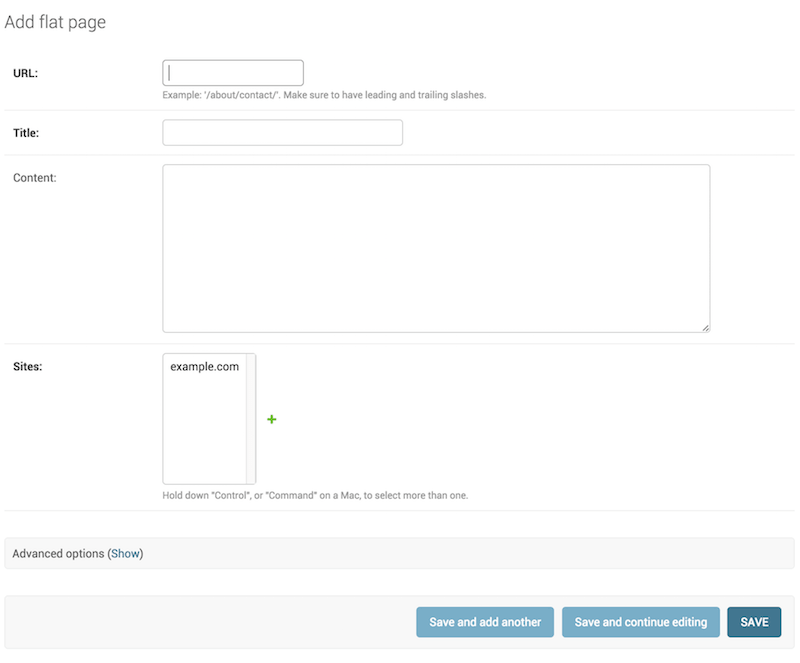

If neither `fieldsets` nor `fields` options are present, Django will default to displaying each field that isn’t an `AutoField` and has `editable=True`, in a single fieldset, in the same order as the fields are defined in the model.

The `field_options` dictionary can have the following keys:

- **`fields`**

  A tuple of field names to display in this fieldset. This key is required.

  Example:

  ```
  {
  'fields': ('first_name', 'last_name', 'address', 'city', 'state'),
  }
  ```

  As with the `fields` option, to display multiple fields on the same line, wrap those fields in their own tuple. In this example, the `first_name` and `last_name` fields will display on the same line:

  ```
  {
  'fields': (('first_name', 'last_name'), 'address', 'city', 'state'),
  }
  ```

  `fields` can contain values defined in `readonly_fields` to be displayed as read-only.

  If you add the name of a callable to `fields`, the same rule applies as with the `fields` option: the callable must be listed in `readonly_fields`.
- **`classes`**

  A list or tuple containing extra CSS classes to apply to the fieldset.

  Example:

  ```
  {
  'classes': ('wide', 'extrapretty'),
  }
  ```

  Two useful classes defined by the default admin site stylesheet are `collapse` and `wide`. Fieldsets with the `collapse` style will be initially collapsed in the admin and replaced with a small “click to expand” link. Fieldsets with the `wide` style will be given extra horizontal space.
- **`description`**

  A string of optional extra text to be displayed at the top of each fieldset, under the heading of the fieldset. This string is not rendered for `TabularInline` due to its layout.

  Note that this value is *not* HTML-escaped when it’s displayed in the admin interface. This lets you include HTML if you so desire. Alternatively you can use plain text and `django.utils.html.escape()` to escape any HTML special characters.

**`ModelAdmin.filter_horizontal`**

By default, a `ManyToManyField` is displayed in the admin site with a `<select multiple>`. However, multiple-select boxes can be difficult to use when selecting many items. Adding a `ManyToManyField` to this list will instead use a nifty unobtrusive JavaScript “filter” interface that allows searching within the options. The unselected and selected options appear in two boxes side by side. See `filter_vertical` to use a vertical interface.

**`ModelAdmin.filter_vertical`**

Same as `filter_horizontal`, but uses a vertical display of the filter interface with the box of unselected options appearing above the box of selected options.

**`ModelAdmin.form`**

By default a `ModelForm` is dynamically created for your model. It is used to create the form presented on both the add/change pages. You can easily provide your own `ModelForm` to override any default form behavior on the add/change pages. Alternatively, you can customize the default form rather than specifying an entirely new one by using the `ModelAdmin.get_form()` method.

For an example see the section Adding custom validation to the admin.

Note

If you define the `Meta.model` attribute on a `ModelForm`, you must also define the `Meta.fields` attribute (or the `Meta.exclude` attribute). However, since the admin has its own way of defining fields, the `Meta.fields` attribute will be ignored.

If the `ModelForm` is only going to be used for the admin, the easiest solution is to omit the `Meta.model` attribute, since `ModelAdmin` will provide the correct model to use. Alternatively, you can set `fields = []` in the `Meta` class to satisfy the validation on the `ModelForm`.

Note

If your `ModelForm` and `ModelAdmin` both define an `exclude` option then `ModelAdmin` takes precedence:

```
from django import forms
from django.contrib import admin
from myapp.models import Person

class PersonForm(forms.ModelForm):

    class Meta:
        model = Person
        exclude = ['name']

class PersonAdmin(admin.ModelAdmin):
    exclude = ['age']
    form = PersonForm
```

In the above example, the “age” field will be excluded but the “name” field will be included in the generated form.

**`ModelAdmin.formfield_overrides`**

This provides a quick-and-dirty way to override some of the `Field` options for use in the admin. `formfield_overrides` is a dictionary mapping a field class to a dict of arguments to pass to the field at construction time.

Since that’s a bit abstract, let’s look at a concrete example. The most common use of `formfield_overrides` is to add a custom widget for a certain type of field. So, imagine we’ve written a `RichTextEditorWidget` that we’d like to use for large text fields instead of the default `<textarea>`. Here’s how we’d do that:

```
from django.contrib import admin
from django.db import models

# Import our custom widget and our model from where they're defined
from myapp.models import MyModel
from myapp.widgets import RichTextEditorWidget

class MyModelAdmin(admin.ModelAdmin):
    formfield_overrides = {
        models.TextField: {'widget': RichTextEditorWidget},
    }
```

Note that the key in the dictionary is the actual field class, *not* a string. The value is another dictionary; these arguments will be passed to the form field’s `__init__()` method. See The Forms API for details.

Warning

If you want to use a custom widget with a relation field (i.e. `ForeignKey` or `ManyToManyField`), make sure you haven’t included that field’s name in `raw_id_fields`, `radio_fields`, or `autocomplete_fields`.

`formfield_overrides` won’t let you change the widget on relation fields that have `raw_id_fields`, `radio_fields`, or `autocomplete_fields` set. That’s because `raw_id_fields`, `radio_fields`, and `autocomplete_fields` imply custom widgets of their own.

**`ModelAdmin.inlines`**

See `InlineModelAdmin` objects below as well as `ModelAdmin.get_formsets_with_inlines()`.

**`ModelAdmin.list_display`**

Set `list_display` to control which fields are displayed on the change list page of the admin.

Example:

```
list_display = ('first_name', 'last_name')
```

If you don’t set `list_display`, the admin site will display a single column that displays the `__str__()` representation of each object.

There are four types of values that can be used in `list_display`. All but the simplest may use the `display()` decorator is used to customize how the field is presented:

- The name of a model field. For example:

  ```
  class PersonAdmin(admin.ModelAdmin):
      list_display = ('first_name', 'last_name')
  ```

- A callable that accepts one argument, the model instance. For example:

  ```
  @admin.display(description='Name')
  def upper_case_name(obj):
      return ("%s %s" % (obj.first_name, obj.last_name)).upper()

  class PersonAdmin(admin.ModelAdmin):
      list_display = (upper_case_name,)
  ```

- A string representing a `ModelAdmin` method that accepts one argument, the model instance. For example:

  ```
  class PersonAdmin(admin.ModelAdmin):
      list_display = ('upper_case_name',)

      @admin.display(description='Name')
      def upper_case_name(self, obj):
          return ("%s %s" % (obj.first_name, obj.last_name)).upper()
  ```

- A string representing a model attribute or method (without any required arguments). For example:

  ```
  from django.contrib import admin
  from django.db import models

  class Person(models.Model):
      name = models.CharField(max_length=50)
      birthday = models.DateField()

      @admin.display(description='Birth decade')
      def decade_born_in(self):
          return '%d’s' % (self.birthday.year // 10 * 10)

  class PersonAdmin(admin.ModelAdmin):
      list_display = ('name', 'decade_born_in')
  ```

A few special cases to note about `list_display`:

- If the field is a `ForeignKey`, Django will display the `__str__()` of the related object.
- `ManyToManyField` fields aren’t supported, because that would entail executing a separate SQL statement for each row in the table. If you want to do this nonetheless, give your model a custom method, and add that method’s name to `list_display`. (See below for more on custom methods in `list_display`.)
- If the field is a `BooleanField`, Django will display a pretty “yes”, “no”, or “unknown” icon instead of `True`, `False`, or `None`.
- If the string given is a method of the model, `ModelAdmin` or a callable, Django will HTML-escape the output by default. To escape user input and allow your own unescaped tags, use `format_html()`.

  Here’s a full example model:

  ```
  from django.contrib import admin
  from django.db import models
  from django.utils.html import format_html

  class Person(models.Model):
      first_name = models.CharField(max_length=50)
      last_name = models.CharField(max_length=50)
      color_code = models.CharField(max_length=6)

      @admin.display
      def colored_name(self):
          return format_html(
              '<span style="color: #{};">{} {}</span>',
              self.color_code,
              self.first_name,
              self.last_name,
          )

  class PersonAdmin(admin.ModelAdmin):
      list_display = ('first_name', 'last_name', 'colored_name')
  ```

- As some examples have already demonstrated, when using a callable, a model method, or a `ModelAdmin` method, you can customize the column’s title by wrapping the callable with the `display()` decorator and passing the `description` argument.

  Changed in Django 3.2:

  The `description` argument to the `display()` decorator is equivalent to setting the `short_description` attribute on the display function directly in previous versions. Setting the attribute directly is still supported for backward compatibility.
- If the value of a field is `None`, an empty string, or an iterable without elements, Django will display `-` (a dash). You can override this with `AdminSite.empty_value_display`:

  ```
  from django.contrib import admin

  admin.site.empty_value_display = '(None)'
  ```

  You can also use `ModelAdmin.empty_value_display`:

  ```
  class PersonAdmin(admin.ModelAdmin):
      empty_value_display = 'unknown'
  ```

  Or on a field level:

  ```
  class PersonAdmin(admin.ModelAdmin):
      list_display = ('name', 'birth_date_view')

      @admin.display(empty_value='unknown')
      def birth_date_view(self, obj):
           return obj.birth_date
  ```

  Changed in Django 3.2:

  The `empty_value` argument to the `display()` decorator is equivalent to setting the `empty_value_display` attribute on the display function directly in previous versions. Setting the attribute directly is still supported for backward compatibility.
- If the string given is a method of the model, `ModelAdmin` or a callable that returns `True`, `False`, or `None`, Django will display a pretty “yes”, “no”, or “unknown” icon if you wrap the method with the `display()` decorator passing the `boolean` argument with the value set to `True`:

  ```
  from django.contrib import admin
  from django.db import models

  class Person(models.Model):
      first_name = models.CharField(max_length=50)
      birthday = models.DateField()

      @admin.display(boolean=True)
      def born_in_fifties(self):
          return 1950 <= self.birthday.year < 1960

  class PersonAdmin(admin.ModelAdmin):
      list_display = ('name', 'born_in_fifties')
  ```

  Changed in Django 3.2:

  The `boolean` argument to the `display()` decorator is equivalent to setting the `boolean` attribute on the display function directly in previous versions. Setting the attribute directly is still supported for backward compatibility.
- The `__str__()` method is just as valid in `list_display` as any other model method, so it’s perfectly OK to do this:

  ```
  list_display = ('__str__', 'some_other_field')
  ```

- Usually, elements of `list_display` that aren’t actual database fields can’t be used in sorting (because Django does all the sorting at the database level).

  However, if an element of `list_display` represents a certain database field, you can indicate this fact by using the `display()` decorator on the method, passing the `ordering` argument:

  ```
  from django.contrib import admin
  from django.db import models
  from django.utils.html import format_html

  class Person(models.Model):
      first_name = models.CharField(max_length=50)
      color_code = models.CharField(max_length=6)

      @admin.display(ordering='first_name')
      def colored_first_name(self):
          return format_html(
              '<span style="color: #{};">{}</span>',
              self.color_code,
              self.first_name,
          )

  class PersonAdmin(admin.ModelAdmin):
      list_display = ('first_name', 'colored_first_name')
  ```

  The above will tell Django to order by the `first_name` field when trying to sort by `colored_first_name` in the admin.

  To indicate descending order with the `ordering` argument you can use a hyphen prefix on the field name. Using the above example, this would look like:

  ```
  @admin.display(ordering='-first_name')
  ```

  The `ordering` argument supports query lookups to sort by values on related models. This example includes an “author first name” column in the list display and allows sorting it by first name:

  ```
  class Blog(models.Model):
      title = models.CharField(max_length=255)
      author = models.ForeignKey(Person, on_delete=models.CASCADE)

  class BlogAdmin(admin.ModelAdmin):
      list_display = ('title', 'author', 'author_first_name')

      @admin.display(ordering='author__first_name')
      def author_first_name(self, obj):
          return obj.author.first_name
  ```

  Query expressions may be used with the `ordering` argument:

  ```
  from django.db.models import Value
  from django.db.models.functions import Concat

  class Person(models.Model):
      first_name = models.CharField(max_length=50)
      last_name = models.CharField(max_length=50)

      @admin.display(ordering=Concat('first_name', Value(' '), 'last_name'))
      def full_name(self):
          return self.first_name + ' ' + self.last_name
  ```

  Changed in Django 3.2:

  The `ordering` argument to the `display()` decorator is equivalent to setting the `admin_order_field` attribute on the display function directly in previous versions. Setting the attribute directly is still supported for backward compatibility.
- Elements of `list_display` can also be properties:

  ```
  class Person(models.Model):
      first_name = models.CharField(max_length=50)
      last_name = models.CharField(max_length=50)

      @property
      @admin.display(
          ordering='last_name',
          description='Full name of the person',
      )
      def full_name(self):
          return self.first_name + ' ' + self.last_name

  class PersonAdmin(admin.ModelAdmin):
      list_display = ('full_name',)
  ```

  Note that `@property` must be above `@display`. If you’re using the old way – setting the display-related attributes directly rather than using the `display()` decorator – be aware that the `property()` function and **not** the `@property` decorator must be used:

  ```
  def my_property(self):
      return self.first_name + ' ' + self.last_name
  my_property.short_description = "Full name of the person"
  my_property.admin_order_field = 'last_name'

  full_name = property(my_property)
  ```

- The field names in `list_display` will also appear as CSS classes in the HTML output, in the form of `column-<field_name>` on each `<th>` element. This can be used to set column widths in a CSS file for example.
- Django will try to interpret every element of `list_display` in this order:
  - A field of the model.
  - A callable.
  - A string representing a `ModelAdmin` attribute.
  - A string representing a model attribute.

  For example if you have `first_name` as a model field and as a `ModelAdmin` attribute, the model field will be used.

**`ModelAdmin.list_display_links`**

Use `list_display_links` to control if and which fields in `list_display` should be linked to the “change” page for an object.

By default, the change list page will link the first column – the first field specified in `list_display` – to the change page for each item. But `list_display_links` lets you change this:

- Set it to `None` to get no links at all.
- Set it to a list or tuple of fields (in the same format as `list_display`) whose columns you want converted to links.

  You can specify one or many fields. As long as the fields appear in `list_display`, Django doesn’t care how many (or how few) fields are linked. The only requirement is that if you want to use `list_display_links` in this fashion, you must define `list_display`.

In this example, the `first_name` and `last_name` fields will be linked on the change list page:

```
class PersonAdmin(admin.ModelAdmin):
    list_display = ('first_name', 'last_name', 'birthday')
    list_display_links = ('first_name', 'last_name')
```

In this example, the change list page grid will have no links:

```
class AuditEntryAdmin(admin.ModelAdmin):
    list_display = ('timestamp', 'message')
    list_display_links = None
```

**`ModelAdmin.list_editable`**

Set `list_editable` to a list of field names on the model which will allow editing on the change list page. That is, fields listed in `list_editable` will be displayed as form widgets on the change list page, allowing users to edit and save multiple rows at once.

Note

`list_editable` interacts with a couple of other options in particular ways; you should note the following rules:

- Any field in `list_editable` must also be in `list_display`. You can’t edit a field that’s not displayed!
- The same field can’t be listed in both `list_editable` and `list_display_links` – a field can’t be both a form and a link.

You’ll get a validation error if either of these rules are broken.

**`ModelAdmin.list_filter`**

Set `list_filter` to activate filters in the right sidebar of the change list page of the admin, as illustrated in the following screenshot:

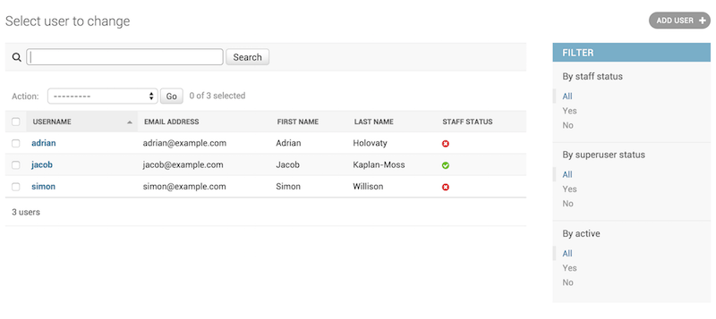

`list_filter` should be a list or tuple of elements, where each element should be of one of the following types:

- a field name, where the specified field should be either a `BooleanField`, `CharField`, `DateField`, `DateTimeField`, `IntegerField`, `ForeignKey` or `ManyToManyField`, for example:

  ```
  class PersonAdmin(admin.ModelAdmin):
      list_filter = ('is_staff', 'company')
  ```

  Field names in `list_filter` can also span relations using the `__` lookup, for example:

  ```
  class PersonAdmin(admin.UserAdmin):
      list_filter = ('company__name',)
  ```

- a class inheriting from `django.contrib.admin.SimpleListFilter`, which you need to provide the `title` and `parameter_name` attributes to and override the `lookups` and `queryset` methods, e.g.:

  ```
  from datetime import date

  from django.contrib import admin
  from django.utils.translation import gettext_lazy as _

  class DecadeBornListFilter(admin.SimpleListFilter):
      # Human-readable title which will be displayed in the
      # right admin sidebar just above the filter options.
      title = _('decade born')

      # Parameter for the filter that will be used in the URL query.
      parameter_name = 'decade'

      def lookups(self, request, model_admin):
          """
          Returns a list of tuples. The first element in each
          tuple is the coded value for the option that will
          appear in the URL query. The second element is the
          human-readable name for the option that will appear
          in the right sidebar.
          """
          return (
              ('80s', _('in the eighties')),
              ('90s', _('in the nineties')),
          )

      def queryset(self, request, queryset):
          """
          Returns the filtered queryset based on the value
          provided in the query string and retrievable via
          `self.value()`.
          """
          # Compare the requested value (either '80s' or '90s')
          # to decide how to filter the queryset.
          if self.value() == '80s':
              return queryset.filter(birthday__gte=date(1980, 1, 1),
                                      birthday__lte=date(1989, 12, 31))
          if self.value() == '90s':
              return queryset.filter(birthday__gte=date(1990, 1, 1),
                                      birthday__lte=date(1999, 12, 31))

  class PersonAdmin(admin.ModelAdmin):
      list_filter = (DecadeBornListFilter,)
  ```

  Note

  As a convenience, the `HttpRequest` object is passed to the `lookups` and `queryset` methods, for example:

  ```
  class AuthDecadeBornListFilter(DecadeBornListFilter):

      def lookups(self, request, model_admin):
          if request.user.is_superuser:
              return super().lookups(request, model_admin)

      def queryset(self, request, queryset):
          if request.user.is_superuser:
              return super().queryset(request, queryset)
  ```

  Also as a convenience, the `ModelAdmin` object is passed to the `lookups` method, for example if you want to base the lookups on the available data:

  ```
  class AdvancedDecadeBornListFilter(DecadeBornListFilter):

      def lookups(self, request, model_admin):
          """
          Only show the lookups if there actually is
          anyone born in the corresponding decades.
          """
          qs = model_admin.get_queryset(request)
          if qs.filter(birthday__gte=date(1980, 1, 1),
                        birthday__lte=date(1989, 12, 31)).exists():
              yield ('80s', _('in the eighties'))
          if qs.filter(birthday__gte=date(1990, 1, 1),
                        birthday__lte=date(1999, 12, 31)).exists():
              yield ('90s', _('in the nineties'))
  ```

- a tuple, where the first element is a field name and the second element is a class inheriting from `django.contrib.admin.FieldListFilter`, for example:

  ```
  class PersonAdmin(admin.ModelAdmin):
      list_filter = (
          ('is_staff', admin.BooleanFieldListFilter),
      )
  ```

  You can limit the choices of a related model to the objects involved in that relation using `RelatedOnlyFieldListFilter`:

  ```
  class BookAdmin(admin.ModelAdmin):
      list_filter = (
          ('author', admin.RelatedOnlyFieldListFilter),
      )
  ```

  Assuming `author` is a `ForeignKey` to a `User` model, this will limit the `list_filter` choices to the users who have written a book instead of listing all users.

  You can filter empty values using `EmptyFieldListFilter`, which can filter on both empty strings and nulls, depending on what the field allows to store:

  ```
  class BookAdmin(admin.ModelAdmin):
      list_filter = (
          ('title', admin.EmptyFieldListFilter),
      )
  ```

  Note

  The `FieldListFilter` API is considered internal and might be changed.

  Note

  The `GenericForeignKey` field is not supported.

List filter’s typically appear only if the filter has more than one choice. A filter’s `has_output()` method controls whether or not it appears.

It is possible to specify a custom template for rendering a list filter:

```
class FilterWithCustomTemplate(admin.SimpleListFilter):
    template = "custom_template.html"
```

See the default template provided by Django (`admin/filter.html`) for a concrete example.

**`ModelAdmin.list_max_show_all`**

Set `list_max_show_all` to control how many items can appear on a “Show all” admin change list page. The admin will display a “Show all” link on the change list only if the total result count is less than or equal to this setting. By default, this is set to `200`.

**`ModelAdmin.list_per_page`**

Set `list_per_page` to control how many items appear on each paginated admin change list page. By default, this is set to `100`.

**`ModelAdmin.list_select_related`**

Set `list_select_related` to tell Django to use `select_related()` in retrieving the list of objects on the admin change list page. This can save you a bunch of database queries.

The value should be either a boolean, a list or a tuple. Default is `False`.

When value is `True`, `select_related()` will always be called. When value is set to `False`, Django will look at `list_display` and call `select_related()` if any `ForeignKey` is present.

If you need more fine-grained control, use a tuple (or list) as value for `list_select_related`. Empty tuple will prevent Django from calling `select_related` at all. Any other tuple will be passed directly to `select_related` as parameters. For example:

```
class ArticleAdmin(admin.ModelAdmin):
    list_select_related = ('author', 'category')
```

will call `select_related('author', 'category')`.

If you need to specify a dynamic value based on the request, you can implement a `get_list_select_related()` method.

Note

`ModelAdmin` ignores this attribute when `select_related()` was already called on the changelist’s `QuerySet`.

**`ModelAdmin.ordering`**

Set `ordering` to specify how lists of objects should be ordered in the Django admin views. This should be a list or tuple in the same format as a model’s `ordering` parameter.

If this isn’t provided, the Django admin will use the model’s default ordering.

If you need to specify a dynamic order (for example depending on user or language) you can implement a `get_ordering()` method.

Performance considerations with ordering and sorting

To ensure a deterministic ordering of results, the changelist adds `pk` to the ordering if it can’t find a single or unique together set of fields that provide total ordering.

For example, if the default ordering is by a non-unique `name` field, then the changelist is sorted by `name` and `pk`. This could perform poorly if you have a lot of rows and don’t have an index on `name` and `pk`.

**`ModelAdmin.paginator`**

The paginator class to be used for pagination. By default, `django.core.paginator.Paginator` is used. If the custom paginator class doesn’t have the same constructor interface as `django.core.paginator.Paginator`, you will also need to provide an implementation for `ModelAdmin.get_paginator()`.

**`ModelAdmin.prepopulated_fields`**

Set `prepopulated_fields` to a dictionary mapping field names to the fields it should prepopulate from:

```
class ArticleAdmin(admin.ModelAdmin):
    prepopulated_fields = {"slug": ("title",)}
```

When set, the given fields will use a bit of JavaScript to populate from the fields assigned. The main use for this functionality is to automatically generate the value for `SlugField` fields from one or more other fields. The generated value is produced by concatenating the values of the source fields, and then by transforming that result into a valid slug (e.g. substituting dashes for spaces and lowercasing ASCII letters).

Prepopulated fields aren’t modified by JavaScript after a value has been saved. It’s usually undesired that slugs change (which would cause an object’s URL to change if the slug is used in it).

`prepopulated_fields` doesn’t accept `DateTimeField`, `ForeignKey`, `OneToOneField`, and `ManyToManyField` fields.

Changed in Django 3.2:

In older versions, various English stop words are removed from generated values.

**`ModelAdmin.preserve_filters`**

By default, applied filters are preserved on the list view after creating, editing, or deleting an object. You can have filters cleared by setting this attribute to `False`.

**`ModelAdmin.radio_fields`**

By default, Django’s admin uses a select-box interface (<select>) for fields that are `ForeignKey` or have `choices` set. If a field is present in `radio_fields`, Django will use a radio-button interface instead. Assuming `group` is a `ForeignKey` on the `Person` model:

```
class PersonAdmin(admin.ModelAdmin):
    radio_fields = {"group": admin.VERTICAL}
```

You have the choice of using `HORIZONTAL` or `VERTICAL` from the `django.contrib.admin` module.

Don’t include a field in `radio_fields` unless it’s a `ForeignKey` or has `choices` set.

**`ModelAdmin.autocomplete_fields`**

`autocomplete_fields` is a list of `ForeignKey` and/or `ManyToManyField` fields you would like to change to [Select2](https://select2.org/) autocomplete inputs.

By default, the admin uses a select-box interface (`<select>`) for those fields. Sometimes you don’t want to incur the overhead of selecting all the related instances to display in the dropdown.

The Select2 input looks similar to the default input but comes with a search feature that loads the options asynchronously. This is faster and more user-friendly if the related model has many instances.

You must define `search_fields` on the related object’s `ModelAdmin` because the autocomplete search uses it.

To avoid unauthorized data disclosure, users must have the `view` or `change` permission to the related object in order to use autocomplete.

Ordering and pagination of the results are controlled by the related `ModelAdmin`’s `get_ordering()` and `get_paginator()` methods.

In the following example, `ChoiceAdmin` has an autocomplete field for the `ForeignKey` to the `Question`. The results are filtered by the `question_text` field and ordered by the `date_created` field:

```
class QuestionAdmin(admin.ModelAdmin):
    ordering = ['date_created']
    search_fields = ['question_text']

class ChoiceAdmin(admin.ModelAdmin):
    autocomplete_fields = ['question']
```

Performance considerations for large datasets

Ordering using `ModelAdmin.ordering` may cause performance problems as sorting on a large queryset will be slow.

Also, if your search fields include fields that aren’t indexed by the database, you might encounter poor performance on extremely large tables.

For those cases, it’s a good idea to write your own `ModelAdmin.get_search_results()` implementation using a full-text indexed search.

You may also want to change the `Paginator` on very large tables as the default paginator always performs a `count()` query. For example, you could override the default implementation of the `Paginator.count` property.

**`ModelAdmin.raw_id_fields`**

By default, Django’s admin uses a select-box interface (<select>) for fields that are `ForeignKey`. Sometimes you don’t want to incur the overhead of having to select all the related instances to display in the drop-down.

`raw_id_fields` is a list of fields you would like to change into an `Input` widget for either a `ForeignKey` or `ManyToManyField`:

```
class ArticleAdmin(admin.ModelAdmin):
    raw_id_fields = ("newspaper",)
```

The `raw_id_fields` `Input` widget should contain a primary key if the field is a `ForeignKey` or a comma separated list of values if the field is a `ManyToManyField`. The `raw_id_fields` widget shows a magnifying glass button next to the field which allows users to search for and select a value:

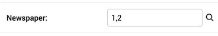

**`ModelAdmin.readonly_fields`**

By default the admin shows all fields as editable. Any fields in this option (which should be a `list` or `tuple`) will display its data as-is and non-editable; they are also excluded from the `ModelForm` used for creating and editing. Note that when specifying `ModelAdmin.fields` or `ModelAdmin.fieldsets` the read-only fields must be present to be shown (they are ignored otherwise).

If `readonly_fields` is used without defining explicit ordering through `ModelAdmin.fields` or `ModelAdmin.fieldsets` they will be added last after all editable fields.

A read-only field can not only display data from a model’s field, it can also display the output of a model’s method or a method of the `ModelAdmin` class itself. This is very similar to the way `ModelAdmin.list_display` behaves. This provides a way to use the admin interface to provide feedback on the status of the objects being edited, for example:

```
from django.contrib import admin
from django.utils.html import format_html_join
from django.utils.safestring import mark_safe

class PersonAdmin(admin.ModelAdmin):
    readonly_fields = ('address_report',)

    # description functions like a model field's verbose_name
    @admin.display(description='Address')
    def address_report(self, instance):
        # assuming get_full_address() returns a list of strings
        # for each line of the address and you want to separate each
        # line by a linebreak
        return format_html_join(
            mark_safe('<br>'),
            '{}',
            ((line,) for line in instance.get_full_address()),
        ) or mark_safe("<span class='errors'>I can't determine this address.</span>")
```

**`ModelAdmin.save_as`**

Set `save_as` to enable a “save as new” feature on admin change forms.

Normally, objects have three save options: “Save”, “Save and continue editing”, and “Save and add another”. If `save_as` is `True`, “Save and add another” will be replaced by a “Save as new” button that creates a new object (with a new ID) rather than updating the existing object.

By default, `save_as` is set to `False`.

**`ModelAdmin.save_as_continue`**

When `save_as=True`, the default redirect after saving the new object is to the change view for that object. If you set `save_as_continue=False`, the redirect will be to the changelist view.

By default, `save_as_continue` is set to `True`.

**`ModelAdmin.save_on_top`**

Set `save_on_top` to add save buttons across the top of your admin change forms.

Normally, the save buttons appear only at the bottom of the forms. If you set `save_on_top`, the buttons will appear both on the top and the bottom.

By default, `save_on_top` is set to `False`.

**`ModelAdmin.search_fields`**

Set `search_fields` to enable a search box on the admin change list page. This should be set to a list of field names that will be searched whenever somebody submits a search query in that text box.

These fields should be some kind of text field, such as `CharField` or `TextField`. You can also perform a related lookup on a `ForeignKey` or `ManyToManyField` with the lookup API “follow” notation:

```
search_fields = ['foreign_key__related_fieldname']
```

For example, if you have a blog entry with an author, the following definition would enable searching blog entries by the email address of the author:

```
search_fields = ['user__email']
```

When somebody does a search in the admin search box, Django splits the search query into words and returns all objects that contain each of the words, case-insensitive (using the `icontains` lookup), where each word must be in at least one of `search_fields`. For example, if `search_fields` is set to `['first_name', 'last_name']` and a user searches for `john lennon`, Django will do the equivalent of this SQL `WHERE` clause:

```
WHERE (first_name ILIKE '%john%' OR last_name ILIKE '%john%')
AND (first_name ILIKE '%lennon%' OR last_name ILIKE '%lennon%')
```

The search query can contain quoted phrases with spaces. For example, if a user searches for `"john winston"` or `'john winston'`, Django will do the equivalent of this SQL `WHERE` clause:

```
WHERE (first_name ILIKE '%john winston%' OR last_name ILIKE '%john winston%')
```

If you don’t want to use `icontains` as the lookup, you can use any lookup by appending it the field. For example, you could use `exact` by setting `search_fields` to `['first_name__exact']`.

Some (older) shortcuts for specifying a field lookup are also available. You can prefix a field in `search_fields` with the following characters and it’s equivalent to adding `__<lookup>` to the field:

| Prefix | Lookup |
| --- | --- |
| ^ | `startswith` |
| = | `iexact` |
| @ | `search` |
| None | `icontains` |

If you need to customize search you can use `ModelAdmin.get_search_results()` to provide additional or alternate search behavior.

Changed in Django 3.2:

Support for searching against quoted phrases with spaces was added.

**`ModelAdmin.search_help_text`**

New in Django 4.0.

Set `search_help_text` to specify a descriptive text for the search box which will be displayed below it.

**`ModelAdmin.show_full_result_count`**

Set `show_full_result_count` to control whether the full count of objects should be displayed on a filtered admin page (e.g. `99 results (103 total)`). If this option is set to `False`, a text like `99 results (Show all)` is displayed instead.

The default of `show_full_result_count=True` generates a query to perform a full count on the table which can be expensive if the table contains a large number of rows.

**`ModelAdmin.sortable_by`**

By default, the change list page allows sorting by all model fields (and callables that use the `ordering` argument to the `display()` decorator or have the `admin_order_field` attribute) specified in `list_display`.

If you want to disable sorting for some columns, set `sortable_by` to a collection (e.g. `list`, `tuple`, or `set`) of the subset of `list_display` that you want to be sortable. An empty collection disables sorting for all columns.

If you need to specify this list dynamically, implement a `get_sortable_by()` method instead.

**`ModelAdmin.view_on_site`**

Set `view_on_site` to control whether or not to display the “View on site” link. This link should bring you to a URL where you can display the saved object.

This value can be either a boolean flag or a callable. If `True` (the default), the object’s `get_absolute_url()` method will be used to generate the url.

If your model has a `get_absolute_url()` method but you don’t want the “View on site” button to appear, you only need to set `view_on_site` to `False`:

```
from django.contrib import admin

class PersonAdmin(admin.ModelAdmin):
    view_on_site = False
```

In case it is a callable, it accepts the model instance as a parameter. For example:

```
from django.contrib import admin
from django.urls import reverse

class PersonAdmin(admin.ModelAdmin):
    def view_on_site(self, obj):
        url = reverse('person-detail', kwargs={'slug': obj.slug})
        return 'https://example.com' + url
```

#### Custom template options

The Overriding admin templates section describes how to override or extend the default admin templates. Use the following options to override the default templates used by the `ModelAdmin` views:

**`ModelAdmin.add_form_template`**

Path to a custom template, used by `add_view()`.

**`ModelAdmin.change_form_template`**

Path to a custom template, used by `change_view()`.

**`ModelAdmin.change_list_template`**

Path to a custom template, used by `changelist_view()`.

**`ModelAdmin.delete_confirmation_template`**

Path to a custom template, used by `delete_view()` for displaying a confirmation page when deleting one or more objects.

**`ModelAdmin.delete_selected_confirmation_template`**

Path to a custom template, used by the `delete_selected` action method for displaying a confirmation page when deleting one or more objects. See the actions documentation.

**`ModelAdmin.object_history_template`**

Path to a custom template, used by `history_view()`.

**`ModelAdmin.popup_response_template`**

Path to a custom template, used by `response_add()`, `response_change()`, and `response_delete()`.

### `ModelAdmin` methods

Warning

When overriding `ModelAdmin.save_model()` and `ModelAdmin.delete_model()`, your code must save/delete the object. They aren’t meant for veto purposes, rather they allow you to perform extra operations.

**`ModelAdmin.save_model(request, obj, form, change)`**

The `save_model` method is given the `HttpRequest`, a model instance, a `ModelForm` instance, and a boolean value based on whether it is adding or changing the object. Overriding this method allows doing pre- or post-save operations. Call `super().save_model()` to save the object using `Model.save()`.

For example to attach `request.user` to the object prior to saving:

```
from django.contrib import admin

class ArticleAdmin(admin.ModelAdmin):
    def save_model(self, request, obj, form, change):
        obj.user = request.user
        super().save_model(request, obj, form, change)
```

**`ModelAdmin.delete_model(request, obj)`**

The `delete_model` method is given the `HttpRequest` and a model instance. Overriding this method allows doing pre- or post-delete operations. Call `super().delete_model()` to delete the object using `Model.delete()`.

**`ModelAdmin.delete_queryset(request, queryset)`**

The `delete_queryset()` method is given the `HttpRequest` and a `QuerySet` of objects to be deleted. Override this method to customize the deletion process for the “delete selected objects” action.

**`ModelAdmin.save_formset(request, form, formset, change)`**

The `save_formset` method is given the `HttpRequest`, the parent `ModelForm` instance and a boolean value based on whether it is adding or changing the parent object.

For example, to attach `request.user` to each changed formset model instance:

```
class ArticleAdmin(admin.ModelAdmin):
    def save_formset(self, request, form, formset, change):
        instances = formset.save(commit=False)
        for obj in formset.deleted_objects:
            obj.delete()
        for instance in instances:
            instance.user = request.user
            instance.save()
        formset.save_m2m()
```

See also Saving objects in the formset.

**`ModelAdmin.get_ordering(request)`**

The `get_ordering` method takes a `request` as parameter and is expected to return a `list` or `tuple` for ordering similar to the `ordering` attribute. For example:

```
class PersonAdmin(admin.ModelAdmin):

    def get_ordering(self, request):
        if request.user.is_superuser:
            return ['name', 'rank']
        else:
            return ['name']
```

**`ModelAdmin.get_search_results(request, queryset, search_term)`**

The `get_search_results` method modifies the list of objects displayed into those that match the provided search term. It accepts the request, a queryset that applies the current filters, and the user-provided search term. It returns a tuple containing a queryset modified to implement the search, and a boolean indicating if the results may contain duplicates.

The default implementation searches the fields named in `ModelAdmin.search_fields`.

This method may be overridden with your own custom search method. For example, you might wish to search by an integer field, or use an external tool such as Solr or Haystack. You must establish if the queryset changes implemented by your search method may introduce duplicates into the results, and return `True` in the second element of the return value.

For example, to search by `name` and `age`, you could use:

```
class PersonAdmin(admin.ModelAdmin):
    list_display = ('name', 'age')
    search_fields = ('name',)

    def get_search_results(self, request, queryset, search_term):
        queryset, may_have_duplicates = super().get_search_results(
            request, queryset, search_term,
        )
        try:
            search_term_as_int = int(search_term)
        except ValueError:
            pass
        else:
            queryset |= self.model.objects.filter(age=search_term_as_int)
        return queryset, may_have_duplicates
```

This implementation is more efficient than

```
search_fields =
('name', '=age')
```

which results in a string comparison for the numeric field, for example `... OR UPPER("polls_choice"."votes"::text) = UPPER('4')` on PostgreSQL.

**`ModelAdmin.save_related(request, form, formsets, change)`**

The `save_related` method is given the `HttpRequest`, the parent `ModelForm` instance, the list of inline formsets and a boolean value based on whether the parent is being added or changed. Here you can do any pre- or post-save operations for objects related to the parent. Note that at this point the parent object and its form have already been saved.

**`ModelAdmin.get_autocomplete_fields(request)`**

The `get_autocomplete_fields()` method is given the `HttpRequest` and is expected to return a `list` or `tuple` of field names that will be displayed with an autocomplete widget as described above in the `ModelAdmin.autocomplete_fields` section.

**`ModelAdmin.get_readonly_fields(request, obj=None)`**

The `get_readonly_fields` method is given the `HttpRequest` and the `obj` being edited (or `None` on an add form) and is expected to return a `list` or `tuple` of field names that will be displayed as read-only, as described above in the `ModelAdmin.readonly_fields` section.

**`ModelAdmin.get_prepopulated_fields(request, obj=None)`**

The `get_prepopulated_fields` method is given the `HttpRequest` and the `obj` being edited (or `None` on an add form) and is expected to return a `dictionary`, as described above in the `ModelAdmin.prepopulated_fields` section.

**`ModelAdmin.get_list_display(request)`**

The `get_list_display` method is given the `HttpRequest` and is expected to return a `list` or `tuple` of field names that will be displayed on the changelist view as described above in the `ModelAdmin.list_display` section.

**`ModelAdmin.get_list_display_links(request, list_display)`**

The `get_list_display_links` method is given the `HttpRequest` and the `list` or `tuple` returned by `ModelAdmin.get_list_display()`. It is expected to return either `None` or a `list` or `tuple` of field names on the changelist that will be linked to the change view, as described in the `ModelAdmin.list_display_links` section.

**`ModelAdmin.get_exclude(request, obj=None)`**

The `get_exclude` method is given the `HttpRequest` and the `obj` being edited (or `None` on an add form) and is expected to return a list of fields, as described in `ModelAdmin.exclude`.

**`ModelAdmin.get_fields(request, obj=None)`**

The `get_fields` method is given the `HttpRequest` and the `obj` being edited (or `None` on an add form) and is expected to return a list of fields, as described above in the `ModelAdmin.fields` section.

**`ModelAdmin.get_fieldsets(request, obj=None)`**

The `get_fieldsets` method is given the `HttpRequest` and the `obj` being edited (or `None` on an add form) and is expected to return a list of two-tuples, in which each two-tuple represents a `<fieldset>` on the admin form page, as described above in the `ModelAdmin.fieldsets` section.

**`ModelAdmin.get_list_filter(request)`**

The `get_list_filter` method is given the `HttpRequest` and is expected to return the same kind of sequence type as for the `list_filter` attribute.

**`ModelAdmin.get_list_select_related(request)`**

The `get_list_select_related` method is given the `HttpRequest` and should return a boolean or list as `ModelAdmin.list_select_related` does.

**`ModelAdmin.get_search_fields(request)`**

The `get_search_fields` method is given the `HttpRequest` and is expected to return the same kind of sequence type as for the `search_fields` attribute.

**`ModelAdmin.get_sortable_by(request)`**

The `get_sortable_by()` method is passed the `HttpRequest` and is expected to return a collection (e.g. `list`, `tuple`, or `set`) of field names that will be sortable in the change list page.

Its default implementation returns `sortable_by` if it’s set, otherwise it defers to `get_list_display()`.

For example, to prevent one or more columns from being sortable:

```
class PersonAdmin(admin.ModelAdmin):

    def get_sortable_by(self, request):
        return {*self.get_list_display(request)} - {'rank'}
```

**`ModelAdmin.get_inline_instances(request, obj=None)`**

The `get_inline_instances` method is given the `HttpRequest` and the `obj` being edited (or `None` on an add form) and is expected to return a `list` or `tuple` of `InlineModelAdmin` objects, as described below in the `InlineModelAdmin` section. For example, the following would return inlines without the default filtering based on add, change, delete, and view permissions:

```
class MyModelAdmin(admin.ModelAdmin):
    inlines = (MyInline,)

    def get_inline_instances(self, request, obj=None):
        return [inline(self.model, self.admin_site) for inline in self.inlines]
```

If you override this method, make sure that the returned inlines are instances of the classes defined in `inlines` or you might encounter a “Bad Request” error when adding related objects.

**`ModelAdmin.get_inlines(request, obj)`**

The `get_inlines` method is given the `HttpRequest` and the `obj` being edited (or `None` on an add form) and is expected to return an iterable of inlines. You can override this method to dynamically add inlines based on the request or model instance instead of specifying them in `ModelAdmin.inlines`.

**`ModelAdmin.get_urls()`**

The `get_urls` method on a `ModelAdmin` returns the URLs to be used for that ModelAdmin in the same way as a URLconf. Therefore you can extend them as documented in URL dispatcher:

```
from django.contrib import admin
from django.template.response import TemplateResponse
from django.urls import path

class MyModelAdmin(admin.ModelAdmin):
    def get_urls(self):
        urls = super().get_urls()
        my_urls = [
            path('my_view/', self.my_view),
        ]
        return my_urls + urls

    def my_view(self, request):
        # ...
        context = dict(
           # Include common variables for rendering the admin template.
           self.admin_site.each_context(request),
           # Anything else you want in the context...
           key=value,
        )
        return TemplateResponse(request, "sometemplate.html", context)
```

If you want to use the admin layout, extend from `admin/base_site.html`:

```
{% extends "admin/base_site.html" %}
{% block content %}
...
{% endblock %}
```

Note

Notice that the custom patterns are included *before* the regular admin URLs: the admin URL patterns are very permissive and will match nearly anything, so you’ll usually want to prepend your custom URLs to the built-in ones.

In this example, `my_view` will be accessed at `/admin/myapp/mymodel/my_view/` (assuming the admin URLs are included at `/admin/`.)

However, the `self.my_view` function registered above suffers from two problems:

- It will *not* perform any permission checks, so it will be accessible to the general public.
- It will *not* provide any header details to prevent caching. This means if the page retrieves data from the database, and caching middleware is active, the page could show outdated information.

Since this is usually not what you want, Django provides a convenience wrapper to check permissions and mark the view as non-cacheable. This wrapper is `AdminSite.admin_view()` (i.e. `self.admin_site.admin_view` inside a `ModelAdmin` instance); use it like so:

```
class MyModelAdmin(admin.ModelAdmin):
    def get_urls(self):
        urls = super().get_urls()
        my_urls = [
            path('my_view/', self.admin_site.admin_view(self.my_view))
        ]
        return my_urls + urls
```

Notice the wrapped view in the fifth line above:

```
path('my_view/', self.admin_site.admin_view(self.my_view))
```

This wrapping will protect `self.my_view` from unauthorized access and will apply the `django.views.decorators.cache.never_cache()` decorator to make sure it is not cached if the cache middleware is active.

If the page is cacheable, but you still want the permission check to be performed, you can pass a `cacheable=True` argument to `AdminSite.admin_view()`:

```
path('my_view/', self.admin_site.admin_view(self.my_view, cacheable=True))
```

`ModelAdmin` views have `model_admin` attributes. Other `AdminSite` views have `admin_site` attributes.

**`ModelAdmin.get_form(request, obj=None, **kwargs)`**

Returns a `ModelForm` class for use in the admin add and change views, see `add_view()` and `change_view()`.

The base implementation uses `modelform_factory()` to subclass `form`, modified by attributes such as `fields` and `exclude`. So, for example, if you wanted to offer additional fields to superusers, you could swap in a different base form like so:

```
class MyModelAdmin(admin.ModelAdmin):
    def get_form(self, request, obj=None, **kwargs):
        if request.user.is_superuser:
            kwargs['form'] = MySuperuserForm
        return super().get_form(request, obj, **kwargs)
```

You may also return a custom `ModelForm` class directly.

**`ModelAdmin.get_formsets_with_inlines(request, obj=None)`**

Yields (`FormSet`, `InlineModelAdmin`) pairs for use in admin add and change views.

For example if you wanted to display a particular inline only in the change view, you could override `get_formsets_with_inlines` as follows:

```
class MyModelAdmin(admin.ModelAdmin):
    inlines = [MyInline, SomeOtherInline]

    def get_formsets_with_inlines(self, request, obj=None):
        for inline in self.get_inline_instances(request, obj):
            # hide MyInline in the add view
            if not isinstance(inline, MyInline) or obj is not None:
                yield inline.get_formset(request, obj), inline
```

**`ModelAdmin.formfield_for_foreignkey(db_field, request, **kwargs)`**

The `formfield_for_foreignkey` method on a `ModelAdmin` allows you to override the default formfield for a foreign keys field. For example, to return a subset of objects for this foreign key field based on the user:

```
class MyModelAdmin(admin.ModelAdmin):
    def formfield_for_foreignkey(self, db_field, request, **kwargs):
        if db_field.name == "car":
            kwargs["queryset"] = Car.objects.filter(owner=request.user)
        return super().formfield_for_foreignkey(db_field, request, **kwargs)
```

This uses the `HttpRequest` instance to filter the `Car` foreign key field to only display the cars owned by the `User` instance.

For more complex filters, you can use `ModelForm.__init__()` method to filter based on an `instance` of your model (see Fields which handle relationships). For example:

```
class CountryAdminForm(forms.ModelForm):
    def __init__(self, *args, **kwargs):
        super().__init__(*args, **kwargs)
        self.fields['capital'].queryset = self.instance.cities.all()

class CountryAdmin(admin.ModelAdmin):
    form = CountryAdminForm
```

**`ModelAdmin.formfield_for_manytomany(db_field, request, **kwargs)`**

Like the `formfield_for_foreignkey` method, the `formfield_for_manytomany` method can be overridden to change the default formfield for a many to many field. For example, if an owner can own multiple cars and cars can belong to multiple owners – a many to many relationship – you could filter the `Car` foreign key field to only display the cars owned by the `User`:

```
class MyModelAdmin(admin.ModelAdmin):
    def formfield_for_manytomany(self, db_field, request, **kwargs):
        if db_field.name == "cars":
            kwargs["queryset"] = Car.objects.filter(owner=request.user)
        return super().formfield_for_manytomany(db_field, request, **kwargs)
```

**`ModelAdmin.formfield_for_choice_field(db_field, request, **kwargs)`**

Like the `formfield_for_foreignkey` and `formfield_for_manytomany` methods, the `formfield_for_choice_field` method can be overridden to change the default formfield for a field that has declared choices. For example, if the choices available to a superuser should be different than those available to regular staff, you could proceed as follows:

```
class MyModelAdmin(admin.ModelAdmin):
    def formfield_for_choice_field(self, db_field, request, **kwargs):
        if db_field.name == "status":
            kwargs['choices'] = (
                ('accepted', 'Accepted'),
                ('denied', 'Denied'),
            )
            if request.user.is_superuser:
                kwargs['choices'] += (('ready', 'Ready for deployment'),)
        return super().formfield_for_choice_field(db_field, request, **kwargs)
```

Note

Any `choices` attribute set on the formfield will be limited to the form field only. If the corresponding field on the model has choices set, the choices provided to the form must be a valid subset of those choices, otherwise the form submission will fail with a `ValidationError` when the model itself is validated before saving.

**`ModelAdmin.get_changelist(request, **kwargs)`**

Returns the `Changelist` class to be used for listing. By default, `django.contrib.admin.views.main.ChangeList` is used. By inheriting this class you can change the behavior of the listing.

**`ModelAdmin.get_changelist_form(request, **kwargs)`**

Returns a `ModelForm` class for use in the `Formset` on the changelist page. To use a custom form, for example:

```
from django import forms

class MyForm(forms.ModelForm):
    pass

class MyModelAdmin(admin.ModelAdmin):
    def get_changelist_form(self, request, **kwargs):
        return MyForm
```

Note

If you define the `Meta.model` attribute on a `ModelForm`, you must also define the `Meta.fields` attribute (or the `Meta.exclude` attribute). However, `ModelAdmin` ignores this value, overriding it with the `ModelAdmin.list_editable` attribute. The easiest solution is to omit the `Meta.model` attribute, since `ModelAdmin` will provide the correct model to use.

**`ModelAdmin.get_changelist_formset(request, **kwargs)`**

Returns a ModelFormSet class for use on the changelist page if `list_editable` is used. To use a custom formset, for example:

```
from django.forms import BaseModelFormSet

class MyAdminFormSet(BaseModelFormSet):
    pass

class MyModelAdmin(admin.ModelAdmin):
    def get_changelist_formset(self, request, **kwargs):
        kwargs['formset'] = MyAdminFormSet
        return super().get_changelist_formset(request, **kwargs)
```

**`ModelAdmin.lookup_allowed(lookup, value)`**

The objects in the changelist page can be filtered with lookups from the URL’s query string. This is how `list_filter` works, for example. The lookups are similar to what’s used in `QuerySet.filter()` (e.g. `user__email=user@example.com`). Since the lookups in the query string can be manipulated by the user, they must be sanitized to prevent unauthorized data exposure.

The `lookup_allowed()` method is given a lookup path from the query string (e.g. `'user__email'`) and the corresponding value (e.g. `'user@example.com'`), and returns a boolean indicating whether filtering the changelist’s `QuerySet` using the parameters is permitted. If `lookup_allowed()` returns `False`, `DisallowedModelAdminLookup` (subclass of `SuspiciousOperation`) is raised.

By default, `lookup_allowed()` allows access to a model’s local fields, field paths used in `list_filter` (but not paths from `get_list_filter()`), and lookups required for `limit_choices_to` to function correctly in `raw_id_fields`.

Override this method to customize the lookups permitted for your `ModelAdmin` subclass.

**`ModelAdmin.has_view_permission(request, obj=None)`**

Should return `True` if viewing `obj` is permitted, `False` otherwise. If obj is `None`, should return `True` or `False` to indicate whether viewing of objects of this type is permitted in general (e.g., `False` will be interpreted as meaning that the current user is not permitted to view any object of this type).

The default implementation returns `True` if the user has either the “change” or “view” permission.

**`ModelAdmin.has_add_permission(request)`**

Should return `True` if adding an object is permitted, `False` otherwise.

**`ModelAdmin.has_change_permission(request, obj=None)`**

Should return `True` if editing `obj` is permitted, `False` otherwise. If `obj` is `None`, should return `True` or `False` to indicate whether editing of objects of this type is permitted in general (e.g., `False` will be interpreted as meaning that the current user is not permitted to edit any object of this type).

**`ModelAdmin.has_delete_permission(request, obj=None)`**

Should return `True` if deleting `obj` is permitted, `False` otherwise. If `obj` is `None`, should return `True` or `False` to indicate whether deleting objects of this type is permitted in general (e.g., `False` will be interpreted as meaning that the current user is not permitted to delete any object of this type).

**`ModelAdmin.has_module_permission(request)`**

Should return `True` if displaying the module on the admin index page and accessing the module’s index page is permitted, `False` otherwise. Uses `User.has_module_perms()` by default. Overriding it does not restrict access to the view, add, change, or delete views, `has_view_permission()`, `has_add_permission()`, `has_change_permission()`, and `has_delete_permission()` should be used for that.

**`ModelAdmin.get_queryset(request)`**

The `get_queryset` method on a `ModelAdmin` returns a `QuerySet` of all model instances that can be edited by the admin site. One use case for overriding this method is to show objects owned by the logged-in user:

```
class MyModelAdmin(admin.ModelAdmin):
    def get_queryset(self, request):
        qs = super().get_queryset(request)
        if request.user.is_superuser:
            return qs
        return qs.filter(author=request.user)
```

**`ModelAdmin.message_user(request, message, level=messages.INFO, extra_tags='', fail_silently=False)`**

Sends a message to the user using the `django.contrib.messages` backend. See the custom ModelAdmin example.

Keyword arguments allow you to change the message level, add extra CSS tags, or fail silently if the `contrib.messages` framework is not installed. These keyword arguments match those for `django.contrib.messages.add_message()`, see that function’s documentation for more details. One difference is that the level may be passed as a string label in addition to integer/constant.

**`ModelAdmin.get_paginator(request, queryset, per_page, orphans=0, allow_empty_first_page=True)`**

Returns an instance of the paginator to use for this view. By default, instantiates an instance of `paginator`.

**`ModelAdmin.response_add(request, obj, post_url_continue=None)`**

Determines the `HttpResponse` for the `add_view()` stage.

`response_add` is called after the admin form is submitted and just after the object and all the related instances have been created and saved. You can override it to change the default behavior after the object has been created.

**`ModelAdmin.response_change(request, obj)`**

Determines the `HttpResponse` for the `change_view()` stage.

`response_change` is called after the admin form is submitted and just after the object and all the related instances have been saved. You can override it to change the default behavior after the object has been changed.

**`ModelAdmin.response_delete(request, obj_display, obj_id)`**

Determines the `HttpResponse` for the `delete_view()` stage.

`response_delete` is called after the object has been deleted. You can override it to change the default behavior after the object has been deleted.

`obj_display` is a string with the name of the deleted object.

`obj_id` is the serialized identifier used to retrieve the object to be deleted.

**`ModelAdmin.get_formset_kwargs(request, obj, inline, prefix)`**

New in Django 4.0.

A hook for customizing the keyword arguments passed to the constructor of a formset. For example, to pass `request` to formset forms:

```
class MyModelAdmin(admin.ModelAdmin):
    def get_formset_kwargs(self, request, obj, inline, prefix):
        return {
            **super().get_formset_kwargs(request, obj, inline, prefix),
            'form_kwargs': {'request': request},
        }
```

You can also used it to set `initial` for formset forms.

**`ModelAdmin.get_changeform_initial_data(request)`**

A hook for the initial data on admin change forms. By default, fields are given initial values from `GET` parameters. For instance, `?name=initial_value` will set the `name` field’s initial value to be `initial_value`.

This method should return a dictionary in the form `{'fieldname': 'fieldval'}`:

```
def get_changeform_initial_data(self, request):
    return {'name': 'custom_initial_value'}
```

**`ModelAdmin.get_deleted_objects(objs, request)`**

A hook for customizing the deletion process of the `delete_view()` and the “delete selected” action.

The `objs` argument is a homogeneous iterable of objects (a `QuerySet` or a list of model instances) to be deleted, and `request` is the `HttpRequest`.

This method must return a 4-tuple of `(deleted_objects, model_count, perms_needed, protected)`.

`deleted_objects` is a list of strings representing all the objects that will be deleted. If there are any related objects to be deleted, the list is nested and includes those related objects. The list is formatted in the template using the `unordered_list` filter.

`model_count` is a dictionary mapping each model’s `verbose_name_plural` to the number of objects that will be deleted.

`perms_needed` is a set of `verbose_name`s of the models that the user doesn’t have permission to delete.

`protected` is a list of strings representing of all the protected related objects that can’t be deleted. The list is displayed in the template.

#### Other methods

**`ModelAdmin.add_view(request, form_url='', extra_context=None)`**

Django view for the model instance addition page. See note below.

**`ModelAdmin.change_view(request, object_id, form_url='', extra_context=None)`**

Django view for the model instance editing page. See note below.

**`ModelAdmin.changelist_view(request, extra_context=None)`**

Django view for the model instances change list/actions page. See note below.

**`ModelAdmin.delete_view(request, object_id, extra_context=None)`**

Django view for the model instance(s) deletion confirmation page. See note below.

**`ModelAdmin.history_view(request, object_id, extra_context=None)`**

Django view for the page that shows the modification history for a given model instance.

Unlike the hook-type `ModelAdmin` methods detailed in the previous section, these five methods are in reality designed to be invoked as Django views from the admin application URL dispatching handler to render the pages that deal with model instances CRUD operations. As a result, completely overriding these methods will significantly change the behavior of the admin application.

One common reason for overriding these methods is to augment the context data that is provided to the template that renders the view. In the following example, the change view is overridden so that the rendered template is provided some extra mapping data that would not otherwise be available:

```
class MyModelAdmin(admin.ModelAdmin):

    # A template for a very customized change view:
    change_form_template = 'admin/myapp/extras/openstreetmap_change_form.html'

    def get_osm_info(self):
        # ...
        pass

    def change_view(self, request, object_id, form_url='', extra_context=None):
        extra_context = extra_context or {}
        extra_context['osm_data'] = self.get_osm_info()
        return super().change_view(
            request, object_id, form_url, extra_context=extra_context,
        )
```

These views return `TemplateResponse` instances which allow you to easily customize the response data before rendering. For more details, see the TemplateResponse documentation.

### `ModelAdmin` asset definitions

There are times where you would like add a bit of CSS and/or JavaScript to the add/change views. This can be accomplished by using a `Media` inner class on your `ModelAdmin`:

```
class ArticleAdmin(admin.ModelAdmin):
    class Media:
        css = {
            "all": ("my_styles.css",)
        }
        js = ("my_code.js",)
```

The staticfiles app prepends `STATIC_URL` (or `MEDIA_URL` if `STATIC_URL` is `None`) to any asset paths. The same rules apply as regular asset definitions on forms.

#### jQuery

Django admin JavaScript makes use of the [jQuery](https://jquery.com) library.

To avoid conflicts with user-supplied scripts or libraries, Django’s jQuery (version 3.6.0) is namespaced as `django.jQuery`. If you want to use jQuery in your own admin JavaScript without including a second copy, you can use the `django.jQuery` object on changelist and add/edit views. Also, your own admin forms or widgets depending on `django.jQuery` must specify `js=['admin/js/jquery.init.js', …]` when declaring form media assets.

Changed in Django 4.0:

jQuery was upgraded from 3.5.1 to 3.6.0.

The `ModelAdmin` class requires jQuery by default, so there is no need to add jQuery to your `ModelAdmin`’s list of media resources unless you have a specific need. For example, if you require the jQuery library to be in the global namespace (for example when using third-party jQuery plugins) or if you need a newer version of jQuery, you will have to include your own copy.

Django provides both uncompressed and ‘minified’ versions of jQuery, as `jquery.js` and `jquery.min.js` respectively.

`ModelAdmin` and `InlineModelAdmin` have a `media` property that returns a list of `Media` objects which store paths to the JavaScript files for the forms and/or formsets. If `DEBUG` is `True` it will return the uncompressed versions of the various JavaScript files, including `jquery.js`; if not, it will return the ‘minified’ versions.

### Adding custom validation to the admin

You can also add custom validation of data in the admin. The automatic admin interface reuses `django.forms`, and the `ModelAdmin` class gives you the ability to define your own form:

```
class ArticleAdmin(admin.ModelAdmin):
    form = MyArticleAdminForm
```

`MyArticleAdminForm` can be defined anywhere as long as you import where needed. Now within your form you can add your own custom validation for any field:

```
class MyArticleAdminForm(forms.ModelForm):
    def clean_name(self):
        # do something that validates your data
        return self.cleaned_data["name"]
```

It is important you use a `ModelForm` here otherwise things can break. See the forms documentation on custom validation and, more specifically, the model form validation notes for more information.

## `InlineModelAdmin` objects

**`class InlineModelAdmin`**

**`class TabularInline`**

**`class StackedInline`**

The admin interface has the ability to edit models on the same page as a parent model. These are called inlines. Suppose you have these two models:

```
from django.db import models

class Author(models.Model):
   name = models.CharField(max_length=100)

class Book(models.Model):
   author = models.ForeignKey(Author, on_delete=models.CASCADE)
   title = models.CharField(max_length=100)
```

You can edit the books authored by an author on the author page. You add inlines to a model by specifying them in a `ModelAdmin.inlines`:

```
from django.contrib import admin

class BookInline(admin.TabularInline):
    model = Book

class AuthorAdmin(admin.ModelAdmin):
    inlines = [
        BookInline,
    ]
```

Django provides two subclasses of `InlineModelAdmin` and they are:

- `TabularInline`
- `StackedInline`

The difference between these two is merely the template used to render them.

### `InlineModelAdmin` options

`InlineModelAdmin` shares many of the same features as `ModelAdmin`, and adds some of its own (the shared features are actually defined in the `BaseModelAdmin` superclass). The shared features are:

- `form`
- `fieldsets`
- `fields`
- `formfield_overrides`
- `exclude`
- `filter_horizontal`
- `filter_vertical`
- `ordering`
- `prepopulated_fields`
- `get_fieldsets()`
- `get_queryset()`
- `radio_fields`
- `readonly_fields`
- `raw_id_fields`
- `formfield_for_choice_field()`
- `formfield_for_foreignkey()`
- `formfield_for_manytomany()`
- `has_module_permission()`

The `InlineModelAdmin` class adds or customizes:

**`InlineModelAdmin.model`**

The model which the inline is using. This is required.

**`InlineModelAdmin.fk_name`**

The name of the foreign key on the model. In most cases this will be dealt with automatically, but `fk_name` must be specified explicitly if there are more than one foreign key to the same parent model.

**`InlineModelAdmin.formset`**

This defaults to `BaseInlineFormSet`. Using your own formset can give you many possibilities of customization. Inlines are built around model formsets.

**`InlineModelAdmin.form`**

The value for `form` defaults to `ModelForm`. This is what is passed through to `inlineformset_factory()` when creating the formset for this inline.

Warning

When writing custom validation for `InlineModelAdmin` forms, be cautious of writing validation that relies on features of the parent model. If the parent model fails to validate, it may be left in an inconsistent state as described in the warning in Validation on a ModelForm.

**`InlineModelAdmin.classes`**

A list or tuple containing extra CSS classes to apply to the fieldset that is rendered for the inlines. Defaults to `None`. As with classes configured in `fieldsets`, inlines with a `collapse` class will be initially collapsed and their header will have a small “show” link.

**`InlineModelAdmin.extra`**

This controls the number of extra forms the formset will display in addition to the initial forms. Defaults to 3. See the formsets documentation for more information.

For users with JavaScript-enabled browsers, an “Add another” link is provided to enable any number of additional inlines to be added in addition to those provided as a result of the `extra` argument.

The dynamic link will not appear if the number of currently displayed forms exceeds `max_num`, or if the user does not have JavaScript enabled.

`InlineModelAdmin.get_extra()` also allows you to customize the number of extra forms.

**`InlineModelAdmin.max_num`**

This controls the maximum number of forms to show in the inline. This doesn’t directly correlate to the number of objects, but can if the value is small enough. See Limiting the number of editable objects for more information.

`InlineModelAdmin.get_max_num()` also allows you to customize the maximum number of extra forms.

**`InlineModelAdmin.min_num`**

This controls the minimum number of forms to show in the inline. See `modelformset_factory()` for more information.

`InlineModelAdmin.get_min_num()` also allows you to customize the minimum number of displayed forms.

**`InlineModelAdmin.raw_id_fields`**

By default, Django’s admin uses a select-box interface (<select>) for fields that are `ForeignKey`. Sometimes you don’t want to incur the overhead of having to select all the related instances to display in the drop-down.

`raw_id_fields` is a list of fields you would like to change into an `Input` widget for either a `ForeignKey` or `ManyToManyField`:

```
class BookInline(admin.TabularInline):
    model = Book
    raw_id_fields = ("pages",)
```

**`InlineModelAdmin.template`**

The template used to render the inline on the page.

**`InlineModelAdmin.verbose_name`**

An override to the `verbose_name` from the model’s inner `Meta` class.

**`InlineModelAdmin.verbose_name_plural`**

An override to the `verbose_name_plural` from the model’s inner `Meta` class. If this isn’t given and the `InlineModelAdmin.verbose_name` is defined, Django will use `InlineModelAdmin.verbose_name` + `'s'`.

Changed in Django 4.0:

The fallback to `InlineModelAdmin.verbose_name` was added.

**`InlineModelAdmin.can_delete`**

Specifies whether or not inline objects can be deleted in the inline. Defaults to `True`.

**`InlineModelAdmin.show_change_link`**

Specifies whether or not inline objects that can be changed in the admin have a link to the change form. Defaults to `False`.

**`InlineModelAdmin.get_formset(request, obj=None, **kwargs)`**

Returns a `BaseInlineFormSet` class for use in admin add/change views. `obj` is the parent object being edited or `None` when adding a new parent. See the example for `ModelAdmin.get_formsets_with_inlines`.

**`InlineModelAdmin.get_extra(request, obj=None, **kwargs)`**

Returns the number of extra inline forms to use. By default, returns the `InlineModelAdmin.extra` attribute.

Override this method to programmatically determine the number of extra inline forms. For example, this may be based on the model instance (passed as the keyword argument `obj`):

```
class BinaryTreeAdmin(admin.TabularInline):
    model = BinaryTree

    def get_extra(self, request, obj=None, **kwargs):
        extra = 2
        if obj:
            return extra - obj.binarytree_set.count()
        return extra
```

**`InlineModelAdmin.get_max_num(request, obj=None, **kwargs)`**

Returns the maximum number of extra inline forms to use. By default, returns the `InlineModelAdmin.max_num` attribute.

Override this method to programmatically determine the maximum number of inline forms. For example, this may be based on the model instance (passed as the keyword argument `obj`):

```
class BinaryTreeAdmin(admin.TabularInline):
    model = BinaryTree

    def get_max_num(self, request, obj=None, **kwargs):
        max_num = 10
        if obj and obj.parent:
            return max_num - 5
        return max_num
```

**`InlineModelAdmin.get_min_num(request, obj=None, **kwargs)`**

Returns the minimum number of inline forms to use. By default, returns the `InlineModelAdmin.min_num` attribute.

Override this method to programmatically determine the minimum number of inline forms. For example, this may be based on the model instance (passed as the keyword argument `obj`).

**`InlineModelAdmin.has_add_permission(request, obj)`**

Should return `True` if adding an inline object is permitted, `False` otherwise. `obj` is the parent object being edited or `None` when adding a new parent.

**`InlineModelAdmin.has_change_permission(request, obj=None)`**

Should return `True` if editing an inline object is permitted, `False` otherwise. `obj` is the parent object being edited.

**`InlineModelAdmin.has_delete_permission(request, obj=None)`**

Should return `True` if deleting an inline object is permitted, `False` otherwise. `obj` is the parent object being edited.

Note

The `obj` argument passed to `InlineModelAdmin` methods is the parent object being edited or `None` when adding a new parent.

### Working with a model with two or more foreign keys to the same parent model

It is sometimes possible to have more than one foreign key to the same model. Take this model for instance:

```
from django.db import models

class Friendship(models.Model):
    to_person = models.ForeignKey(Person, on_delete=models.CASCADE, related_name="friends")
    from_person = models.ForeignKey(Person, on_delete=models.CASCADE, related_name="from_friends")
```

If you wanted to display an inline on the `Person` admin add/change pages you need to explicitly define the foreign key since it is unable to do so automatically:

```
from django.contrib import admin
from myapp.models import Friendship

class FriendshipInline(admin.TabularInline):
    model = Friendship
    fk_name = "to_person"

class PersonAdmin(admin.ModelAdmin):
    inlines = [
        FriendshipInline,
    ]
```

### Working with many-to-many models

By default, admin widgets for many-to-many relations will be displayed on whichever model contains the actual reference to the `ManyToManyField`. Depending on your `ModelAdmin` definition, each many-to-many field in your model will be represented by a standard HTML `<select multiple>`, a horizontal or vertical filter, or a `raw_id_fields` widget. However, it is also possible to replace these widgets with inlines.

Suppose we have the following models:

```
from django.db import models

class Person(models.Model):
    name = models.CharField(max_length=128)

class Group(models.Model):
    name = models.CharField(max_length=128)
    members = models.ManyToManyField(Person, related_name='groups')
```

If you want to display many-to-many relations using an inline, you can do so by defining an `InlineModelAdmin` object for the relationship:

```
from django.contrib import admin

class MembershipInline(admin.TabularInline):
    model = Group.members.through

class PersonAdmin(admin.ModelAdmin):
    inlines = [
        MembershipInline,
    ]

class GroupAdmin(admin.ModelAdmin):
    inlines = [
        MembershipInline,
    ]
    exclude = ('members',)
```

There are two features worth noting in this example.

Firstly - the `MembershipInline` class references `Group.members.through`. The `through` attribute is a reference to the model that manages the many-to-many relation. This model is automatically created by Django when you define a many-to-many field.

Secondly, the `GroupAdmin` must manually exclude the `members` field. Django displays an admin widget for a many-to-many field on the model that defines the relation (in this case, `Group`). If you want to use an inline model to represent the many-to-many relationship, you must tell Django’s admin to *not* display this widget - otherwise you will end up with two widgets on your admin page for managing the relation.

Note that when using this technique the `m2m_changed` signals aren’t triggered. This is because as far as the admin is concerned, `through` is just a model with two foreign key fields rather than a many-to-many relation.

In all other respects, the `InlineModelAdmin` is exactly the same as any other. You can customize the appearance using any of the normal `ModelAdmin` properties.

### Working with many-to-many intermediary models

When you specify an intermediary model using the `through` argument to a `ManyToManyField`, the admin will not display a widget by default. This is because each instance of that intermediary model requires more information than could be displayed in a single widget, and the layout required for multiple widgets will vary depending on the intermediate model.

However, we still want to be able to edit that information inline. Fortunately, we can do this with inline admin models. Suppose we have the following models:

```
from django.db import models

class Person(models.Model):
    name = models.CharField(max_length=128)

class Group(models.Model):
    name = models.CharField(max_length=128)
    members = models.ManyToManyField(Person, through='Membership')

class Membership(models.Model):
    person = models.ForeignKey(Person, on_delete=models.CASCADE)
    group = models.ForeignKey(Group, on_delete=models.CASCADE)
    date_joined = models.DateField()
    invite_reason = models.CharField(max_length=64)
```

The first step in displaying this intermediate model in the admin is to define an inline class for the `Membership` model:

```
class MembershipInline(admin.TabularInline):
    model = Membership
    extra = 1
```

This example uses the default `InlineModelAdmin` values for the `Membership` model, and limits the extra add forms to one. This could be customized using any of the options available to `InlineModelAdmin` classes.

Now create admin views for the `Person` and `Group` models:

```
class PersonAdmin(admin.ModelAdmin):
    inlines = (MembershipInline,)

class GroupAdmin(admin.ModelAdmin):
    inlines = (MembershipInline,)
```

Finally, register your `Person` and `Group` models with the admin site:

```
admin.site.register(Person, PersonAdmin)
admin.site.register(Group, GroupAdmin)
```

Now your admin site is set up to edit `Membership` objects inline from either the `Person` or the `Group` detail pages.

### Using generic relations as an inline

It is possible to use an inline with generically related objects. Let’s say you have the following models:

```
from django.contrib.contenttypes.fields import GenericForeignKey
from django.db import models

class Image(models.Model):
    image = models.ImageField(upload_to="images")
    content_type = models.ForeignKey(ContentType, on_delete=models.CASCADE)
    object_id = models.PositiveIntegerField()
    content_object = GenericForeignKey("content_type", "object_id")

class Product(models.Model):
    name = models.CharField(max_length=100)
```

If you want to allow editing and creating an `Image` instance on the `Product`, add/change views you can use `GenericTabularInline` or `GenericStackedInline` (both subclasses of `GenericInlineModelAdmin`) provided by `admin`. They implement tabular and stacked visual layouts for the forms representing the inline objects, respectively, just like their non-generic counterparts. They behave just like any other inline. In your `admin.py` for this example app:

```
from django.contrib import admin
from django.contrib.contenttypes.admin import GenericTabularInline

from myapp.models import Image, Product

class ImageInline(GenericTabularInline):
    model = Image

class ProductAdmin(admin.ModelAdmin):
    inlines = [
        ImageInline,
    ]

admin.site.register(Product, ProductAdmin)
```

See the contenttypes documentation for more specific information.

## Overriding admin templates

You can override many of the templates which the admin module uses to generate the various pages of an admin site. You can even override a few of these templates for a specific app, or a specific model.

### Set up your projects admin template directories

The admin template files are located in the `contrib/admin/templates/admin` directory.

In order to override one or more of them, first create an `admin` directory in your project’s `templates` directory. This can be any of the directories you specified in the `DIRS` option of the `DjangoTemplates` backend in the `TEMPLATES` setting. If you have customized the `'loaders'` option, be sure `'django.template.loaders.filesystem.Loader'` appears before `'django.template.loaders.app_directories.Loader'` so that your custom templates will be found by the template loading system before those that are included with `django.contrib.admin`.

Within this `admin` directory, create sub-directories named after your app. Within these app subdirectories create sub-directories named after your models. Note, that the admin app will lowercase the model name when looking for the directory, so make sure you name the directory in all lowercase if you are going to run your app on a case-sensitive filesystem.

To override an admin template for a specific app, copy and edit the template from the `django/contrib/admin/templates/admin` directory, and save it to one of the directories you just created.

For example, if we wanted to add a tool to the change list view for all the models in an app named `my_app`, we would copy `contrib/admin/templates/admin/change_list.html` to the `templates/admin/my_app/` directory of our project, and make any necessary changes.

If we wanted to add a tool to the change list view for only a specific model named ‘Page’, we would copy that same file to the `templates/admin/my_app/page` directory of our project.

### Overriding vs. replacing an admin template

Because of the modular design of the admin templates, it is usually neither necessary nor advisable to replace an entire template. It is almost always better to override only the section of the template which you need to change.

To continue the example above, we want to add a new link next to the `History` tool for the `Page` model. After looking at `change_form.html` we determine that we only need to override the `object-tools-items` block. Therefore here is our new `change_form.html` :

```
{% extends "admin/change_form.html" %}
{% load i18n admin_urls %}
{% block object-tools-items %}
    <li>
        <a href="{% url opts|admin_urlname:'history' original.pk|admin_urlquote %}" class="historylink">{% translate "History" %}</a>
    </li>
    <li>
        <a href="mylink/" class="historylink">My Link</a>
    </li>
    {% if has_absolute_url %}
        <li>
            <a href="{% url 'admin:view_on_site' content_type_id original.pk %}" class="viewsitelink">{% translate "View on site" %}</a>
        </li>
    {% endif %}
{% endblock %}
```

And that’s it! If we placed this file in the `templates/admin/my_app` directory, our link would appear on the change form for all models within my_app.

### Templates which may be overridden per app or model

Not every template in `contrib/admin/templates/admin` may be overridden per app or per model. The following can:

- `actions.html`
- `app_index.html`
- `change_form.html`
- `change_form_object_tools.html`
- `change_list.html`
- `change_list_object_tools.html`
- `change_list_results.html`
- `date_hierarchy.html`
- `delete_confirmation.html`
- `object_history.html`
- `pagination.html`
- `popup_response.html`
- `prepopulated_fields_js.html`
- `search_form.html`
- `submit_line.html`

For those templates that cannot be overridden in this way, you may still override them for your entire project by placing the new version in your `templates/admin` directory. This is particularly useful to create custom 404 and 500 pages.

Note

Some of the admin templates, such as `change_list_results.html` are used to render custom inclusion tags. These may be overridden, but in such cases you are probably better off creating your own version of the tag in question and giving it a different name. That way you can use it selectively.

### Root and login templates

If you wish to change the index, login or logout templates, you are better off creating your own `AdminSite` instance (see below), and changing the `AdminSite.index_template` , `AdminSite.login_template` or `AdminSite.logout_template` properties.

## Theming support

New in Django 3.2.

The admin uses CSS variables to define colors. This allows changing colors without having to override many individual CSS rules. For example, if you preferred purple instead of blue you could add a `admin/base.html` template override to your project:

```
{% extends 'admin/base.html' %}

{% block extrastyle %}{{ block.super }}
<style>
:root {
  --primary: #9774d5;
  --secondary: #785cab;
  --link-fg: #7c449b;
  --link-selected-fg: #8f5bb2;
}
</style>
{% endblock %}
```

A dark theme is defined, and applied respecting the prefers-color-scheme media query.

The list of CSS variables are defined at `django/contrib/admin/static/admin/css/base.css`.

## `AdminSite` objects

**`class AdminSite(name='admin')`**

A Django administrative site is represented by an instance of `django.contrib.admin.sites.AdminSite`; by default, an instance of this class is created as `django.contrib.admin.site` and you can register your models and `ModelAdmin` instances with it.

If you want to customize the default admin site, you can override it.

When constructing an instance of an `AdminSite`, you can provide a unique instance name using the `name` argument to the constructor. This instance name is used to identify the instance, especially when reversing admin URLs. If no instance name is provided, a default instance name of `admin` will be used. See Customizing the AdminSite class for an example of customizing the `AdminSite` class.

### `AdminSite` attributes

Templates can override or extend base admin templates as described in Overriding admin templates.

**`AdminSite.site_header`**

The text to put at the top of each admin page, as an `<h1>` (a string). By default, this is “Django administration”.

**`AdminSite.site_title`**

The text to put at the end of each admin page’s `<title>` (a string). By default, this is “Django site admin”.

**`AdminSite.site_url`**

The URL for the “View site” link at the top of each admin page. By default, `site_url` is `/`. Set it to `None` to remove the link.

For sites running on a subpath, the `each_context()` method checks if the current request has `request.META['SCRIPT_NAME']` set and uses that value if `site_url` isn’t set to something other than `/`.

**`AdminSite.index_title`**

The text to put at the top of the admin index page (a string). By default, this is “Site administration”.

**`AdminSite.index_template`**

Path to a custom template that will be used by the admin site main index view.

**`AdminSite.app_index_template`**

Path to a custom template that will be used by the admin site app index view.

**`AdminSite.empty_value_display`**

The string to use for displaying empty values in the admin site’s change list. Defaults to a dash. The value can also be overridden on a per `ModelAdmin` basis and on a custom field within a `ModelAdmin` by setting an `empty_value_display` attribute on the field. See `ModelAdmin.empty_value_display` for examples.

**`AdminSite.enable_nav_sidebar`**

A boolean value that determines whether to show the navigation sidebar on larger screens. By default, it is set to `True`.

**`AdminSite.final_catch_all_view`**

New in Django 3.2.

A boolean value that determines whether to add a final catch-all view to the admin that redirects unauthenticated users to the login page. By default, it is set to `True`.

Warning

Setting this to `False` is not recommended as the view protects against a potential model enumeration privacy issue.

**`AdminSite.login_template`**

Path to a custom template that will be used by the admin site login view.

**`AdminSite.login_form`**

Subclass of `AuthenticationForm` that will be used by the admin site login view.

**`AdminSite.logout_template`**

Path to a custom template that will be used by the admin site logout view.

**`AdminSite.password_change_template`**

Path to a custom template that will be used by the admin site password change view.

**`AdminSite.password_change_done_template`**

Path to a custom template that will be used by the admin site password change done view.

### `AdminSite` methods

**`AdminSite.each_context(request)`**

Returns a dictionary of variables to put in the template context for every page in the admin site.

Includes the following variables and values by default:

- `site_header`: `AdminSite.site_header`
- `site_title`: `AdminSite.site_title`
- `site_url`: `AdminSite.site_url`
- `has_permission`: `AdminSite.has_permission()`
- `available_apps`: a list of applications from the application registry available for the current user. Each entry in the list is a dict representing an application with the following keys:
  - `app_label`: the application label
  - `app_url`: the URL of the application index in the admin
  - `has_module_perms`: a boolean indicating if displaying and accessing of the module’s index page is permitted for the current user
  - `models`: a list of the models available in the application

  Each model is a dict with the following keys:
  - `model`: the model class
  - `object_name`: class name of the model
  - `name`: plural name of the model
  - `perms`: a `dict` tracking `add`, `change`, `delete`, and `view` permissions
  - `admin_url`: admin changelist URL for the model
  - `add_url`: admin URL to add a new model instance

Changed in Django 4.0:

The `model` variable for each model was added.

**`AdminSite.has_permission(request)`**

Returns `True` if the user for the given `HttpRequest` has permission to view at least one page in the admin site. Defaults to requiring both `User.is_active` and `User.is_staff` to be `True`.

**`AdminSite.register(model_or_iterable, admin_class=None, **options)`**

Registers the given model class (or iterable of classes) with the given `admin_class`. `admin_class` defaults to `ModelAdmin` (the default admin options). If keyword arguments are given – e.g. `list_display` – they’ll be applied as options to the admin class.

Raises `ImproperlyConfigured` if a model is abstract. and `django.contrib.admin.sites.AlreadyRegistered` if a model is already registered.

**`AdminSite.unregister(model_or_iterable)`**

Unregisters the given model class (or iterable of classes).

Raises `django.contrib.admin.sites.NotRegistered` if a model isn’t already registered.

### Hooking `AdminSite` instances into your URLconf

The last step in setting up the Django admin is to hook your `AdminSite` instance into your URLconf. Do this by pointing a given URL at the `AdminSite.urls` method. It is not necessary to use `include()`.

In this example, we register the default `AdminSite` instance `django.contrib.admin.site` at the URL `/admin/`

```
# urls.py
from django.contrib import admin
from django.urls import path

urlpatterns = [
    path('admin/', admin.site.urls),
]
```

### Customizing the `AdminSite` class

If you’d like to set up your own admin site with custom behavior, you’re free to subclass `AdminSite` and override or add anything you like. Then, create an instance of your `AdminSite` subclass (the same way you’d instantiate any other Python class) and register your models and `ModelAdmin` subclasses with it instead of with the default site. Finally, update `myproject/urls.py` to reference your `AdminSite` subclass.

myapp/admin.py

```
from django.contrib.admin import AdminSite

from .models import MyModel

class MyAdminSite(AdminSite):
    site_header = 'Monty Python administration'

admin_site = MyAdminSite(name='myadmin')
admin_site.register(MyModel)
```

myproject/urls.py

```
from django.urls import path

from myapp.admin import admin_site

urlpatterns = [
    path('myadmin/', admin_site.urls),
]
```

Note that you may not want autodiscovery of `admin` modules when using your own `AdminSite` instance since you will likely be importing all the per-app `admin` modules in your `myproject.admin` module. This means you need to put `'django.contrib.admin.apps.SimpleAdminConfig'` instead of `'django.contrib.admin'` in your `INSTALLED_APPS` setting.

### Overriding the default admin site

You can override the default `django.contrib.admin.site` by setting the `default_site` attribute of a custom `AppConfig` to the dotted import path of either a `AdminSite` subclass or a callable that returns a site instance.

myproject/admin.py

```
from django.contrib import admin

class MyAdminSite(admin.AdminSite):
    ...
```

myproject/apps.py

```
from django.contrib.admin.apps import AdminConfig

class MyAdminConfig(AdminConfig):
    default_site = 'myproject.admin.MyAdminSite'
```

myproject/settings.py

```
INSTALLED_APPS = [
    ...
    'myproject.apps.MyAdminConfig',  # replaces 'django.contrib.admin'
    ...
]
```

### Multiple admin sites in the same URLconf

You can create multiple instances of the admin site on the same Django-powered website. Create multiple instances of `AdminSite` and place each one at a different URL.

In this example, the URLs `/basic-admin/` and `/advanced-admin/` feature separate versions of the admin site – using the `AdminSite` instances `myproject.admin.basic_site` and `myproject.admin.advanced_site`, respectively:

```
# urls.py
from django.urls import path
from myproject.admin import advanced_site, basic_site

urlpatterns = [
    path('basic-admin/', basic_site.urls),
    path('advanced-admin/', advanced_site.urls),
]
```

`AdminSite` instances take a single argument to their constructor, their name, which can be anything you like. This argument becomes the prefix to the URL names for the purposes of reversing them. This is only necessary if you are using more than one `AdminSite`.

### Adding views to admin sites

Just like `ModelAdmin`, `AdminSite` provides a `get_urls()` method that can be overridden to define additional views for the site. To add a new view to your admin site, extend the base `get_urls()` method to include a pattern for your new view.

Note

Any view you render that uses the admin templates, or extends the base admin template, should set `request.current_app` before rendering the template. It should be set to either `self.name` if your view is on an `AdminSite` or `self.admin_site.name` if your view is on a `ModelAdmin`.

### Adding a password reset feature

You can add a password reset feature to the admin site by adding a few lines to your URLconf. Specifically, add these four patterns:

```
from django.contrib.auth import views as auth_views

path(
    'admin/password_reset/',
    auth_views.PasswordResetView.as_view(),
    name='admin_password_reset',
),
path(
    'admin/password_reset/done/',
    auth_views.PasswordResetDoneView.as_view(),
    name='password_reset_done',
),
path(
    'reset/<uidb64>/<token>/',
    auth_views.PasswordResetConfirmView.as_view(),
    name='password_reset_confirm',
),
path(
    'reset/done/',
    auth_views.PasswordResetCompleteView.as_view(),
    name='password_reset_complete',
),
```

(This assumes you’ve added the admin at `admin/` and requires that you put the URLs starting with `^admin/` before the line that includes the admin app itself).

The presence of the `admin_password_reset` named URL will cause a “forgotten your password?” link to appear on the default admin log-in page under the password box.

## `LogEntry` objects

**`class models.LogEntry`**

The `LogEntry` class tracks additions, changes, and deletions of objects done through the admin interface.

### `LogEntry` attributes

**`LogEntry.action_time`**

The date and time of the action.

**`LogEntry.user`**

The user (an `AUTH_USER_MODEL` instance) who performed the action.

**`LogEntry.content_type`**

The `ContentType` of the modified object.

**`LogEntry.object_id`**

The textual representation of the modified object’s primary key.

**`LogEntry.object_repr`**

The object`s `repr()` after the modification.

**`LogEntry.action_flag`**

The type of action logged: `ADDITION`, `CHANGE`, `DELETION`.

For example, to get a list of all additions done through the admin:

```
from django.contrib.admin.models import ADDITION, LogEntry

LogEntry.objects.filter(action_flag=ADDITION)
```

**`LogEntry.change_message`**

The detailed description of the modification. In the case of an edit, for example, the message contains a list of the edited fields. The Django admin site formats this content as a JSON structure, so that `get_change_message()` can recompose a message translated in the current user language. Custom code might set this as a plain string though. You are advised to use the `get_change_message()` method to retrieve this value instead of accessing it directly.

### `LogEntry` methods

**`LogEntry.get_edited_object()`**

A shortcut that returns the referenced object.

**`LogEntry.get_change_message()`**

Formats and translates `change_message` into the current user language. Messages created before Django 1.10 will always be displayed in the language in which they were logged.

## Reversing admin URLs

When an `AdminSite` is deployed, the views provided by that site are accessible using Django’s URL reversing system.

The `AdminSite` provides the following named URL patterns:

| Page | URL name | Parameters |
| --- | --- | --- |
| Index | `index` |  |
| Login | `login` |  |
| Logout | `logout` |  |
| Password change | `password_change` |  |
| Password change done | `password_change_done` |  |
| i18n JavaScript | `jsi18n` |  |
| Application index page | `app_list` | `app_label` |
| Redirect to object’s page | `view_on_site` | `content_type_id`, `object_id` |

Each `ModelAdmin` instance provides an additional set of named URLs:

| Page | URL name | Parameters |
| --- | --- | --- |
| Changelist | `{{ app_label }}_{{ model_name }}_changelist` |  |
| Add | `{{ app_label }}_{{ model_name }}_add` |  |
| History | `{{ app_label }}_{{ model_name }}_history` | `object_id` |
| Delete | `{{ app_label }}_{{ model_name }}_delete` | `object_id` |
| Change | `{{ app_label }}_{{ model_name }}_change` | `object_id` |

The `UserAdmin` provides a named URL:

| Page | URL name | Parameters |
| --- | --- | --- |
| Password change | `auth_user_password_change` | `user_id` |

These named URLs are registered with the application namespace `admin`, and with an instance namespace corresponding to the name of the Site instance.

So - if you wanted to get a reference to the Change view for a particular `Choice` object (from the polls application) in the default admin, you would call:

```
>>> from django.urls import reverse
>>> c = Choice.objects.get(...)
>>> change_url = reverse('admin:polls_choice_change', args=(c.id,))
```

This will find the first registered instance of the admin application (whatever the instance name), and resolve to the view for changing `poll.Choice` instances in that instance.

If you want to find a URL in a specific admin instance, provide the name of that instance as a `current_app` hint to the reverse call. For example, if you specifically wanted the admin view from the admin instance named `custom`, you would need to call:

```
>>> change_url = reverse('admin:polls_choice_change', args=(c.id,), current_app='custom')
```

For more details, see the documentation on reversing namespaced URLs.

To allow easier reversing of the admin urls in templates, Django provides an `admin_urlname` filter which takes an action as argument:

```
{% load admin_urls %}
<a href="{% url opts|admin_urlname:'add' %}">Add user</a>
<a href="{% url opts|admin_urlname:'delete' user.pk %}">Delete this user</a>
```

The action in the examples above match the last part of the URL names for `ModelAdmin` instances described above. The `opts` variable can be any object which has an `app_label` and `model_name` attributes and is usually supplied by the admin views for the current model.

## The `display` decorator

**`display(*, boolean=None, ordering=None, description=None, empty_value=None)`**

New in Django 3.2.

This decorator can be used for setting specific attributes on custom display functions that can be used with `list_display` or `readonly_fields`:

```
@admin.display(
    boolean=True,
    ordering='-publish_date',
    description='Is Published?',
)
def is_published(self, obj):
    return obj.publish_date is not None
```

This is equivalent to setting some attributes (with the original, longer names) on the function directly:

```
def is_published(self, obj):
    return obj.publish_date is not None
is_published.boolean = True
is_published.admin_order_field = '-publish_date'
is_published.short_description = 'Is Published?'
```

Also note that the `empty_value` decorator parameter maps to the `empty_value_display` attribute assigned directly to the function. It cannot be used in conjunction with `boolean` – they are mutually exclusive.

Use of this decorator is not compulsory to make a display function, but it can be useful to use it without arguments as a marker in your source to identify the purpose of the function:

```
@admin.display
def published_year(self, obj):
    return obj.publish_date.year
```

In this case it will add no attributes to the function.

## The `staff_member_required` decorator

**`staff_member_required(redirect_field_name='next', login_url='admin:login')`**

This decorator is used on the admin views that require authorization. A view decorated with this function will have the following behavior:

- If the user is logged in, is a staff member (`User.is_staff=True`), and is active (`User.is_active=True`), execute the view normally.
- Otherwise, the request will be redirected to the URL specified by the `login_url` parameter, with the originally requested path in a query string variable specified by `redirect_field_name`. For example: `/admin/login/?next=/admin/polls/question/3/`.

Example usage:

```
from django.contrib.admin.views.decorators import staff_member_required

@staff_member_required
def my_view(request):
    ...
```

© Django Software Foundation and individual contributors  
Licensed under the BSD License.  
https://docs.djangoproject.com/en/4.0/ref/contrib/admin/index/